# Eksploracyjna Analiza Danych

Badanie zależności dotyczących rocznego wynagrodzenia

Amelia Madej

2023-11-15

# Wprowadzenie

Zestaw danych `Salary` dostarcza informacji o wynagrodzeniach z różnych branż i regionów na całym świecie. Pozyskane z renomowanych stron z ofertami pracy i ankiet, dane zawierają szczegóły dotyczące tytułów zawodowych, zarobków, płci, rasy i innych istotnych aspektów.

Źródło: https://www.kaggle.com/datasets/amirmahdiabbootalebi/salary-by-job-title-and-country

# Zmienne występujące w zestawie danych

**Wiek:** Zmienna liczbowa reprezentująca wiek respondentów.

**Płeć:** Zmienna tekstowa określająca płeć respondentów (`Male`/`Female`).

**Poziom wykształcenia:** Zmienna numeryczna, gdzie: `0` - High School, `1` - Bachelor’s Degree, `2` - Master’s Degree, `3` - Doctor of Philosophy

**Tytuł zawodowy:** Zmienna tekstowa opisująca tytuł zawodowy.

**Lata doświadczenia:** Zmienna liczbowa przedstawiająca liczbę lat doświadczenia zawodowego respondentów.

**Wynagrodzenie roczne:** Zmienna liczbowa reprezentująca roczne wynagrodzenie.

**Kraj:** Zmienna tekstowa informująca o kraju, w którym pracują respondenci (`Australia`, `Canada`, `China`, `UK`, `USA`).

**Rasa:** Zmienna tekstowa opisująca rasę respondentów (`Asian`, `Black`, `Mixed`, `White`).

**Senior:** Zmienna logiczna (`TRUE`/`FALSE`), informująca, czy respondent zajmuje stanowisko seniorskie.

**Dział:** Zmienna opisująca przynależność respondentów do określonego działu.

*Uwaga:* Zmienna `Department` została utworzona w celu usprawnienia analizy dotyczącej zmiennej `Job.Title`.

# Niezbędne pakiety

```r
library(dplyr)
library(tidyverse)
library(ggplot2)
library(mice)
library(corrplot)
library(RColorBrewer)
library(psych)
```

# Przygotowanie i eksploracja danych

Wczytuję plik `Salary.csv` do R:

```r
setwd("C:/Users/Amelia/Desktop/AGH/III semestr/Wstep do analizy danych/EDA-Salary")
Salary <- read.csv("Salary.csv")
```

Wyświetlam podstawowe informacje o zestawie danych `Salary`.

```r
head(Salary)
```

|  | Age | Gender | Education.Level | Job.Title | Years.of.Experience | Salary | Country | Race | Senior |
| --- | --- | --- | --- | --- | --- | --- | --- | --- | --- |
| 1 | 32 | Male | 1 | Software Engineer | 5 | 90000 | UK | White | 0 |
| 2 | 28 | Female | 2 | Data Analyst | 3 | 65000 | USA | Hispanic | 0 |
| 3 | 45 | Male | 3 | Manager | 15 | 150000 | Canada | White | 1 |
| 4 | 36 | Female | 1 | Sales Associate | 7 | 60000 | USA | Hispanic | 0 |
| 5 | 52 | Male | 2 | Director | 20 | 200000 | USA | Asian | 0 |
| 6 | 29 | Male | 1 | Marketing Analyst | 2 | 55000 | USA | Hispanic | 0 |

```r
tail(Salary)
```

|  | Age | Gender | Education.Level | Job.Title | Years.of.Experience | Salary | Country | Race | Senior |
| --- | --- | --- | --- | --- | --- | --- | --- | --- | --- |
| 6679 | 37 | Male | 1 | Sales Representative | 6 | 75000 | Canada | Asian | 0 |
| 6680 | 49 | Female | 3 | Director of Marketing | 20 | 200000 | UK | Mixed | 0 |
| 6681 | 32 | Male | 0 | Sales Associate | 3 | 50000 | Australia | Australian | 0 |
| 6682 | 30 | Female | 1 | Financial Manager | 4 | 55000 | China | Chinese | 0 |
| 6683 | 46 | Male | 2 | Marketing Manager | 14 | 140000 | China | Korean | 0 |
| 6684 | 26 | Female | 0 | Sales Executive | 1 | 35000 | Canada | Black | 0 |

Sprawdzam strukturę zestawu danych:

```r
str(Salary)
```

```
## 'data.frame':    6684 obs. of  9 variables:
##  $ Age                : num  32 28 45 36 52 29 42 31 26 38 ...
##  $ Gender             : chr  "Male" "Female" "Male" "Female" ...
##  $ Education.Level    : int  1 2 3 1 2 1 2 1 1 3 ...
##  $ Job.Title          : chr  "Software Engineer" "Data Analyst" "Manager" "Sales Associate" ...
##  $ Years.of.Experience: num  5 3 15 7 20 2 12 4 1 10 ...
##  $ Salary             : num  90000 65000 150000 60000 200000 55000 120000 80000 45000 110000 ...
##  $ Country            : chr  "UK" "USA" "Canada" "USA" ...
##  $ Race               : chr  "White" "Hispanic" "White" "Hispanic" ...
##  $ Senior             : int  0 0 1 0 0 0 0 0 0 1 ...
```

Zauważam, że liczba różnych stanowisk pracy jest duża, posługuję się funkcją `table()`, aby dowiedzieć się ile osób zajmuje poszczególne stanowiska.

```r
table(Salary$Job.Title)
```

```
##
##                Account Executive                  Account Manager
##                                1                                4
##                       Accountant         Administrative Assistant
##                                6                                2
##          Advertising Coordinator               Back end Developer
##                                1                              242
##                 Business Analyst   Business Development Associate
##                               20                                7
##     Business Development Manager    Business Intelligence Analyst
##                                5                                1
##      Business Operations Analyst                              CEO
##                                2                                1
##               Chief Data Officer         Chief Technology Officer
##                                1                                1
##                       Consultant        Content Marketing Manager
##                                1                               73
##                       Copywriter                Creative Director
##                                2                                1
##         Customer Service Manager             Customer Service Rep
##                                2                                1
##  Customer Service Representative         Customer Success Manager
##                                6                                1
##             Customer Success Rep      Customer Support Specialist
##                                1                                1
##                     Data Analyst                    Data Engineer
##                              391                                4
##                 Data Entry Clerk                   Data Scientist
##                                1                              515
##                  Delivery Driver                         Designer
##                                5                                1
##                        Developer         Digital Content Producer
##                                1                                1
##        Digital Marketing Manager     Digital Marketing Specialist
##                               52                               15
##                         Director Director of Business Development
##                                1                                1
##         Director of Data Science          Director of Engineering
##                               57                                2
##              Director of Finance                   Director of HR
```

[output cut: 76 more lines]

```
##                                1                                1
##              Strategy Consultant             Supply Chain Analyst
##                                1                                1
##             Supply Chain Manager              Technical Recruiter
##                                1                                1
##     Technical Support Specialist                 Technical Writer
##                                1                                1
##              Training Specialist                      UX Designer
##                                2                                5
##                    UX Researcher                    VP of Finance
##                                1                                1
##                 VP of Operations                     Web Designer
##                                1                                1
##                    Web Developer
##                              129
```

```r
length(unique(Salary$Job.Title))
```

```
## [1] 129
```

Liczba różnych stanowisk jest duża, a w niektórych nazwach jedyną różnicę stanowi wielkość liter, zatem przekształcam wszystkie litery w tytułach stanowisk na małe, aby umożliwić jednolite porównanie.

```r
Salary$Job.Title <- tolower(Salary$Job.Title)
table(Salary$Job.Title)
```

```
##
##                account executive                  account manager
##                                1                                4
##                       accountant         administrative assistant
##                                6                                2
##          advertising coordinator               back end developer
##                                1                              242
##                 business analyst   business development associate
##                               20                                7
##     business development manager    business intelligence analyst
##                                5                                1
##      business operations analyst                              ceo
##                                2                                1
##               chief data officer         chief technology officer
##                                1                                1
##                       consultant        content marketing manager
##                                1                               73
##                       copywriter                creative director
##                                2                                1
##         customer service manager             customer service rep
##                                2                                1
##  customer service representative         customer success manager
##                                6                                1
##             customer success rep      customer support specialist
##                                1                                1
##                     data analyst                    data engineer
##                              391                                4
##                 data entry clerk                   data scientist
##                                1                              515
##                  delivery driver                         designer
##                                5                                1
##                        developer         digital content producer
##                                1                                1
##        digital marketing manager     digital marketing specialist
##                               52                               15
##                         director director of business development
##                                1                                1
##         director of data science          director of engineering
##                               57                                2
##              director of finance                   director of hr
```

[output cut: 74 more lines]

```
##                              376                                1
##         software project manager              strategy consultant
##                                1                                1
##             supply chain analyst             supply chain manager
##                                1                                1
##              technical recruiter     technical support specialist
##                                1                                1
##                 technical writer              training specialist
##                                1                                2
##                      ux designer                    ux researcher
##                                5                                1
##                    vp of finance                 vp of operations
##                                1                                1
##                     web designer                    web developer
##                                1                              129
```

```r
length(unique(Salary$Job.Title))
```

```
## [1] 128
```

Ze względu na dużą liczbę różnych stanowisk pracy tworzę nową zmienną `Department`, która będzie przydzielała stanowiska do odpowiednich dla nich działów np. `software engineer` będzie w dziale `IT`. Umożliwi mi to analizę wynagrodzeń, doświadczenia, czy innych zmiennych w kontekście poszczególnych działów.

```r
Salary <- Salary %>%
  mutate(Job.Title = trimws(Job.Title)) %>%

  mutate("Department" = case_when(
    Job.Title %in% c("account executive", "account manager", "accountant", "director of finance", "financial advisor", "financial analyst", "financial manager", "vp of finance") ~ "finance",

    Job.Title %in% c("advertising coordinator", "content marketing manager", "copywriter", "creative director", "digital content producer", "digital marketing manager", "digital marketing specialist", "director of marketing", "marketing analyst", "marketing coordinator", "marketing director", "marketing manager", "marketing specialist", "product marketing manager", "social media man", "social media manager", "social media specialist", "public relations manager") ~ "marketing",

    Job.Title %in% c("administrative assistant", "manager", "office manager", "project coordinator", "strategy consultant", "event coordinator", "director", "ceo") ~ "administration",

    Job.Title %in% c("back end developer", "chief technology officer", "developer", "front end developer", "full stack engineer", "graphic designer", "it consultant", "it manager", "it project manager", "it support", "it support specialist", "network engineer", "software architect", "software developer", "software engineer", "software engineer manager", "software manager", "software project manager", "ux designer", "ux researcher", "web designer", "web developer", "director of engineering", "engineer", "principal engineer", "principal scientist", "help desk analyst", "project engineer", "project manager", "technical support specialist", "technical writer", "designer") ~ "IT",

    Job.Title %in% c("business analyst", "business development associate", "business development manager", "business intelligence analyst", "business operations analyst", "director of business development") ~ "business development",

    Job.Title %in% c("chief data officer", "data analyst", "data engineer", "data entry clerk", "data scientist", "director of data science", "quality assurance analyst", "research director", "research scientist", "researcher", "scientist") ~ "data",

    Job.Title %in% c("customer service manager", "customer service rep", "customer service representative", "customer success manager", "customer success rep", "customer support specialist", "receptionist", "consultant") ~ "customer service",

    Job.Title %in% c("director of hr", "director of human capital", "director of human resources", "hr coordinator", "hr generalist", "hr manager", "hr specialist", "human resources coordinator", "human resources director", "human resources manager", "human resources specialist", "juniour hr coordinator", "juniour hr generalist", "recruiter", "technical recruiter", "training specialist") ~ "HR",


    Job.Title %in% c("director of operations", "operations analyst", "operations coordinator", "operations director", "operations manager", "vp of operations", "supply chain analyst", "supply chain manager", "delivery driver") ~ "operations",


    Job.Title %in% c("director of sales", "director of product management", "director of sales and marketing", "product designer", "product development manager", "product manager", "sales associate", "sales director", "sales executive", "sales manager", "sales operations manager", "sales representative") ~ "sales",
    TRUE ~ "inne"
  ))
```

Sprawdzam, które stanowiska występują więcej niż 50 razy, wykorzystuję do tego pakiet `dplyr`.

```r
Salary %>%
  group_by(Job.Title) %>%
  summarise(count = n()) %>%
  filter(count > 50)
```

| Job.Title | count |
| --- | --- |
| back end developer | 242 |
| content marketing manager | 73 |
| data analyst | 391 |
| data scientist | 515 |
| digital marketing manager | 52 |
| director of data science | 57 |
| director of hr | 69 |
| director of marketing | 88 |
| financial analyst | 53 |
| financial manager | 139 |

[output cut: 24 more lines]

```r
selected_job_titles <- Salary %>%
  mutate(Job.Title = trimws(Job.Title)) %>%
  mutate("Muteated" = case_when(

    Job.Title %in% c("marketing manager", "marketing director", "marketing coordinator", "director of marketing", "content marketing manager", "digital marketing manager", "social media man", "social media manager", "advertising coordinator", "content marketing manager", "creative director", "digital marketing manager", "product marketing manager", "social media manager", "public relations manager") ~ "marketing professional",

    Job.Title %in% c("hr coordinator", "hr manager", "human resources coordinator", "human resources director", "human resources manager", "director of hr", "director of human resources", "juniour hr coordinator", "director of human capital") ~ "hr professional",

    Job.Title %in% c("sales director", "sales executive", "sales manager", "director of sales", "director of sales and marketing", "sales operations manager", "director of product management", "product development manager", "product manager") ~ "sales professional",

    Job.Title %in% c("customer service manager", "customer success manager", "customer service rep", "customer success rep", "customer support specialist") ~ "customer service professional",

    Job.Title %in% c("data analyst", "data engineer", "data entry clerk") ~ "data analyst",

    Job.Title %in% c("chief data officer", "director of data science") ~ "data science professional",

    Job.Title %in% c("account manager", "director of finance", "financial manager", "financial advisor", "vp of finance") ~ "financial professional",

    Job.Title %in% c("product development manager", "product manager", "director of product management", "product development manager") ~ "product manager",

    Job.Title %in% c("project coordinator", "project manager") ~ "project manager",

    TRUE ~ Job.Title)) %>%
  group_by(Job.Title) %>%
  summarise(count = n()) %>%
  filter(count > 50) %>%
  pull(Job.Title)


Salary <- Salary %>%
  mutate(Job.Title = case_when(
    !Job.Title %in% selected_job_titles ~ "other",
    TRUE ~ Job.Title
  ))


Salary <- Salary %>%
  filter(Job.Title %in% c(selected_job_titles, "other")) %>%
  droplevels()

table(Salary$Job.Title)
```

```
##
##        back end developer content marketing manager              data analyst
##                       242                        73                       391
##            data scientist digital marketing manager  director of data science
##                       515                        52                        57
##            director of hr     director of marketing         financial analyst
##                        69                        88                        53
##         financial manager       front end developer       full stack engineer
##                       139                       270                       304
##             hr generalist   human resources manager         marketing analyst
##                       104                       152                       144
##     marketing coordinator        marketing director         marketing manager
##                       167                        65                       315
##        operations manager                     other          product designer
##                       122                       408                        80
##           product manager product marketing manager          project engineer
##                       323                        70                       317
##              receptionist         research director        research scientist
##                        57                        75                       119
##           sales associate            sales director             sales manager
##                       212                        62                        58
##      sales representative        software developer         software engineer
##                        81                       186                       809
## software engineer manager             web developer
##                       376                       129
```

W strukturze zestawu danych widnieje też podejrzanie duża liczba zadeklarowanych ras, aby bliżej przyjrzeć się tej sytuacji, sprawdzam unikalne poziomy tej zmiennej:

```r
table(Salary$Race)
```

```
##
## African American            Asian       Australian            Black
##              352             1599              452              435
##          Chinese         Hispanic           Korean            Mixed
##              443              322              457              334
##            Welsh            White
##              333             1957
```

Liczba zadeklarowanych ras jest całkiem spora. Dokonuję pewnego uproszczonego podziału osób na podstawie informacji o pochodzeniu etnicznym. Rozważam następujący sposób klasyfikacji:

**Biała (White):**

- White
- Welsh
- Australian

**Czarna (Black):**

- Black
- African American

**Azjatycka (Asian):**

- Asian
- Chinese
- Korean

**Mieszana (Mixed):**

- “Hispanic”
- “Mixed”

W tym celu ponownie wykorzystuję funkcję `case_when()` do określenia konkretnych warunków dotyczących ustalonego podziału. Usuwam nieużywane nazwy kategorii dla zmiennej `Race` wykorzystując funkcję `droplevels()`.

```r
Salary <- Salary %>%
  mutate(Race = case_when(
  Race %in% c("White", "Welsh", "Australian") ~ "White",
  Race %in% c("Black", "African American") ~ "Black",
  Race %in% c("Asian", "Chinese", "Korean") ~ "Asian",
  Race %in% c("Hispanic", "Mixed") ~ "Mixed",
  TRUE ~ Race)) %>%
  droplevels()
```

Sprawdzam ponownie liczność każdej z ras:

```r
table(Salary$Race)
```

```
##
## Asian Black Mixed White
##  2499   787   656  2742
```

Sprawdzam ponownie strukturę pliku, aby przyjrzeć się rodzajom zmiennych:

```r
str(Salary)
```

```
## 'data.frame':    6684 obs. of  10 variables:
##  $ Age                : num  32 28 45 36 52 29 42 31 26 38 ...
##  $ Gender             : chr  "Male" "Female" "Male" "Female" ...
##  $ Education.Level    : int  1 2 3 1 2 1 2 1 1 3 ...
##  $ Job.Title          : chr  "software engineer" "data analyst" "other" "sales associate" ...
##  $ Years.of.Experience: num  5 3 15 7 20 2 12 4 1 10 ...
##  $ Salary             : num  90000 65000 150000 60000 200000 55000 120000 80000 45000 110000 ...
##  $ Country            : chr  "UK" "USA" "Canada" "USA" ...
##  $ Race               : chr  "White" "Mixed" "White" "Mixed" ...
##  $ Senior             : int  0 0 1 0 0 0 0 0 0 1 ...
##  $ Department         : chr  "IT" "data" "administration" "sales" ...
```

Można zauważyć, że zestaw danych `Salary` zawiera całkiem sporo zmiennych tekstowych. Zamieniam je na zmienne typu `factor`, aby były rozróżnialne. Zmienną `senior` zamieniam na zmienną typu `logical`.

```r
Salary$Education.Level <- as.factor(Salary$Education.Level)
Salary$Gender <- as.factor(Salary$Gender)
Salary$Job.Title <- as.factor(Salary$Job.Title)
Salary$Country <- as.factor(Salary$Country)
Salary$Race <- as.factor(Salary$Race)
Salary$Department <- as.factor(Salary$Department)
Salary$Senior <- as.logical(Salary$Senior)

str(Salary)
```

```
## 'data.frame':    6684 obs. of  10 variables:
##  $ Age                : num  32 28 45 36 52 29 42 31 26 38 ...
##  $ Gender             : Factor w/ 2 levels "Female","Male": 2 1 2 1 2 2 1 2 1 2 ...
##  $ Education.Level    : Factor w/ 4 levels "0","1","2","3": 2 3 4 2 3 2 3 2 2 4 ...
##  $ Job.Title          : Factor w/ 35 levels "back end developer",..: 33 3 20 28 20 15 22 30 16 20 ...
##  $ Years.of.Experience: num  5 3 15 7 20 2 12 4 1 10 ...
##  $ Salary             : num  90000 65000 150000 60000 200000 55000 120000 80000 45000 110000 ...
##  $ Country            : Factor w/ 5 levels "Australia","Canada",..: 4 5 2 5 5 5 5 3 3 1 ...
##  $ Race               : Factor w/ 4 levels "Asian","Black",..: 4 3 4 3 1 3 1 1 1 4 ...
##  $ Senior             : logi  FALSE FALSE TRUE FALSE FALSE FALSE ...
##  $ Department         : Factor w/ 10 levels "administration",..: 7 4 1 10 1 8 10 10 8 4 ...
```

Weryfikuję obecność braków danych w moim zestawie danych za pomocą funkcji `md.pattern()` z pakietu `mice`.

```r
mice::md.pattern(Salary, rotate.names = TRUE)
```

```
##  /\     /\
## {  `---'  }
## {  O   O  }
## ==>  V <==  No need for mice. This data set is completely observed.
##  \  \|/  /
##   `-----'
```

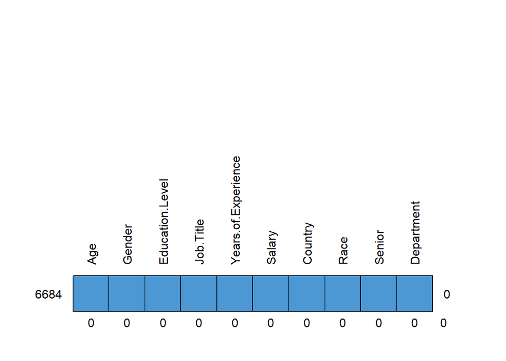

```
##      Age Gender Education.Level Job.Title Years.of.Experience Salary Country
## 6684   1      1               1         1                   1      1       1
##        0      0               0         0                   0      0       0
##      Race Senior Department
## 6684    1      1          1 0
##         0      0          0 0
```

Jak widać - w moim zestawie danych nie występują wartości brakujące.

Wyświetlam podstawowe statystyki opisowe dla zestawu danych `Salary`.

```r
summary(Salary)
```

```
##       Age           Gender     Education.Level                     Job.Title
##  Min.   :21.00   Female:3013   0: 436          software engineer        : 809
##  1st Qu.:28.00   Male  :3671   1:3021          data scientist           : 515
##  Median :32.00                 2:1858          other                    : 408
##  Mean   :33.61                 3:1369          data analyst             : 391
##  3rd Qu.:38.00                                 software engineer manager: 376
##  Max.   :62.00                                 product manager          : 323
##                                                (Other)                  :3862
##  Years.of.Experience     Salary            Country        Race
##  Min.   : 0.000      Min.   :   350   Australia:1335   Asian:2499
##  1st Qu.: 3.000      1st Qu.: 70000   Canada   :1322   Black: 787
##  Median : 7.000      Median :115000   China    :1339   Mixed: 656
##  Mean   : 8.078      Mean   :115307   UK       :1332   White:2742
##  3rd Qu.:12.000      3rd Qu.:160000   USA      :1356
##  Max.   :34.000      Max.   :250000
##
##    Senior            Department
##  Mode :logical   IT       :2720
##  FALSE:5725      data     :1168
##  TRUE :959       marketing:1023
##                  sales    : 859
##                  HR       : 427
##                  finance  : 211
##                  (Other)  : 276
```

Wykorzystuję funkcję `describe()` do wyświetlenia większej ilości statystyk opisowych dla zmiennych ilościowych.

```r
Salary %>%
  select(Age, Years.of.Experience, Salary) %>%
  describe()
```

|  | vars | n | mean | sd | median | trimmed | mad | min | max | range | skew | kurtosis | se |
| --- | --- | --- | --- | --- | --- | --- | --- | --- | --- | --- | --- | --- | --- |
| Age | 1 | 6684 | 3.361056e+01 | 7.595994 | 32 | 3.281189e+01 | 7.4130 | 21 | 62 | 41 | 0.90335964 | 0.1848245 | 0.09291085 |
| Years.of.Experience | 2 | 6684 | 8.077723e+00 | 6.029305 | 7 | 7.433527e+00 | 5.9304 | 0 | 34 | 34 | 0.96527629 | 0.7117000 | 0.07374779 |
| Salary | 3 | 6684 | 1.153072e+05 | 52806.810881 | 115000 | 1.151437e+05 | 66717.0000 | 350 | 250000 | 249650 | 0.05820701 | -1.1671832 | 645.90957066 |

Na podstawie przeglądu statystyk opisowych można podejrzewać obecność wartości odstających zarówno dla zmiennej `Age`, jak i dla zmiennej `Years.of.Experience`.

Aby lepiej zilustrować to zjawisko, użyję wykresu pudełkowego dla zmiennych `Age`, `Years.of.Experience` oraz `Salary`.

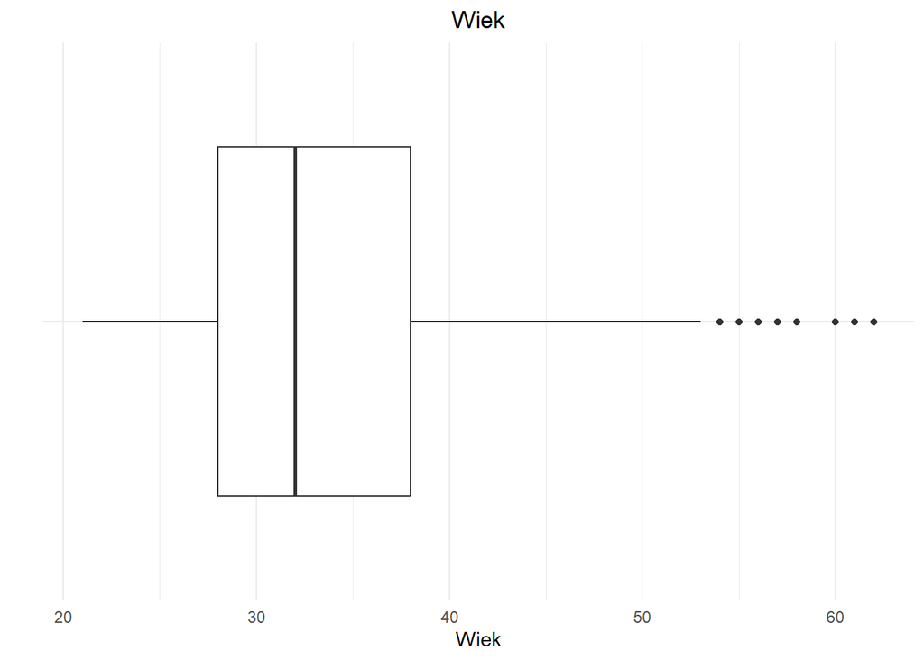

```r
# Wykres pudełkowy dla zmiennej Age
Salary %>%
  ggplot(aes(x = "", y = Age)) +
  geom_boxplot() +
  labs(title = "Wiek", x = "", y = "Wiek") +
  theme_minimal()+
  theme(plot.title = element_text(hjust = 0.5)) +
  coord_flip()
```

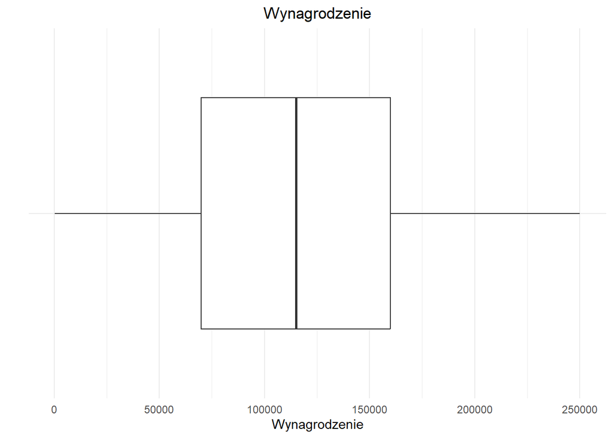

```r
# Wykres pudełkowy dla zmiennej Salary
Salary %>%
  ggplot(aes(x = "", y = Salary)) +
  geom_boxplot() +
  labs(title = "Wynagrodzenie", x = "", y = "Wynagrodzenie") +
  theme_minimal() +
  theme(plot.title = element_text(hjust = 0.5)) +
  coord_flip()
```

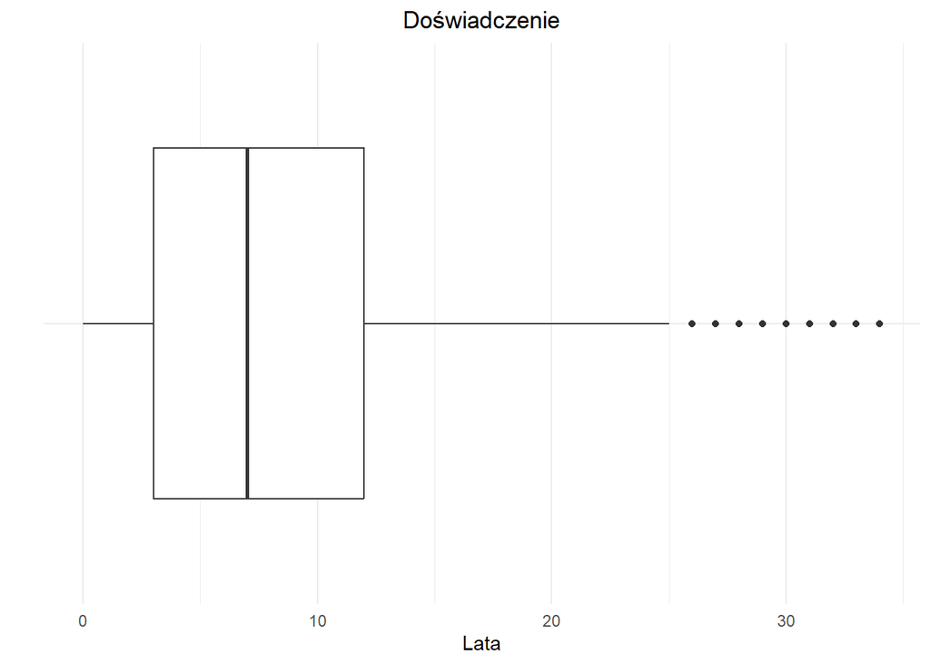

```r
# Wykres pudełkowy dla zmiennej Years.of.Experience
Salary %>%
  ggplot(aes(x = "", y = Years.of.Experience)) +
  geom_boxplot() +
  labs(title = "Doświadczenie", x = "", y = "Lata") +
  theme_minimal() +
  theme(plot.title = element_text(hjust = 0.5)) +
  coord_flip()
```

Wykresy pudełkowe również sugerują występowanie wartości odstających dla wcześniej wspomnianych zmiennych. Sprawdźmy jednak jaka jest ich ilość. Do zrobienia tego tworzę funkcję `number_of_outliers()` i stosuję ją dla zmiennych `Age` oraz `Years.of.Experience`.

```r
number_of_outliers <- function(data){
  Q1 = quantile(data, 0.25)
  Q3 = quantile(data, 0.75)

  IQR = Q3 - Q1

  lower_bound = Q1 - 1.5*IQR
  upper_bound = Q3 + 1.5*IQR

  return(sum(data<lower_bound | data > upper_bound))
}

# Liczba wartości odstających dla zmiennej Age
number_of_outliers(Salary$Age)
```

```
## [1] 119
```

```r
# Liczba wartości odstających dla zmiennej Years.of.Experience
number_of_outliers(Salary$Years.of.Experience)
```

```
## [1] 69
```

Ilość obserwacji odstających w przypadku obu zmiennych nie jest znacząca w porównaniu do ogólnej liczby dostępnych danych w całym zestawie. Niemniej jednak, z uwagi na ich potencjalne cenne informacje, nie decyduję się ich usuwać. Te wartości odstające mogą być istotne dla dalszej analizy wynagrodzeń i wniosków w kontekście specyfiki danych.

# Zmienne ilościowe

## Zmienna Age

Przyglądam się zmiennej `Age`:

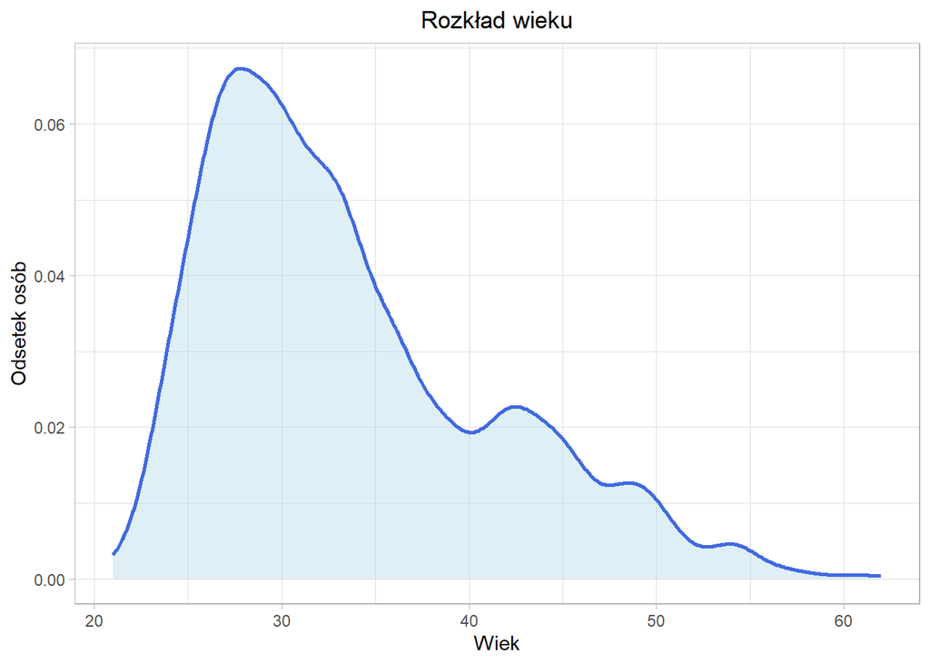

```r
Salary %>%
  ggplot() +
  geom_density(mapping = aes(x = Age),
               color = "royalblue",
               fill = "lightblue",
               alpha = 0.4,
               linewidth = 1) +
  theme_light() +
  theme(plot.title = element_text(hjust = 0.5)) +
  labs(title = "Rozkład wieku",
       x = "Wiek",
       y = "Odsetek osób")
```

```r
summary(Salary$Age)
```

```
##    Min. 1st Qu.  Median    Mean 3rd Qu.    Max.
##   21.00   28.00   32.00   33.61   38.00   62.00
```

Rozkład powyższej cechy jest prawostronnie skośny. Widzimy, że w zestawie danych występują osoby w wieku od 21 do 62 lat. Największa ilość osób znajduje się w przedzale od 28 do 38 lat. Niewielka jest jednak liczba osób starszych (na co wskazywała nam już liczba wartości odstających).

## Zmienna Years.of.Experience

Przyglądam się zmiennej `Years.of.Experience`:

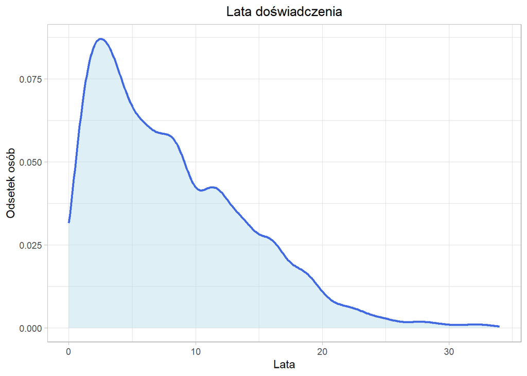

```r
Salary %>%
  ggplot()+
  geom_density(mapping = aes(x = Years.of.Experience),
               color = "royalblue",
               fill = "lightblue",
               alpha = 0.4,
               linewidth = 1) +
  theme_light() +
  theme(plot.title = element_text(hjust = 0.5)) +
  labs(title = "Lata doświadczenia",
       x = "Lata",
       y = "Odsetek osób")
```

```r
summary(Salary$Years.of.Experience)
```

```
##    Min. 1st Qu.  Median    Mean 3rd Qu.    Max.
##   0.000   3.000   7.000   8.078  12.000  34.000
```

Widzimy, że zmienna `Years.of.Experience` również ma rozkład prawostronnie skośny. Liczba lat doświadczenia znajduje się w przedziale od 0 do 34 lat. Największa liczba osób znajduje się w przedziale od 3 do 12 lat doświadczenia. Liczba osób z doświadczeniem większym niż 25 lat jest stosunkowo niewielka.

## Zmienna Salary

Sprawdzam rozkład zmiennej `Salary`:

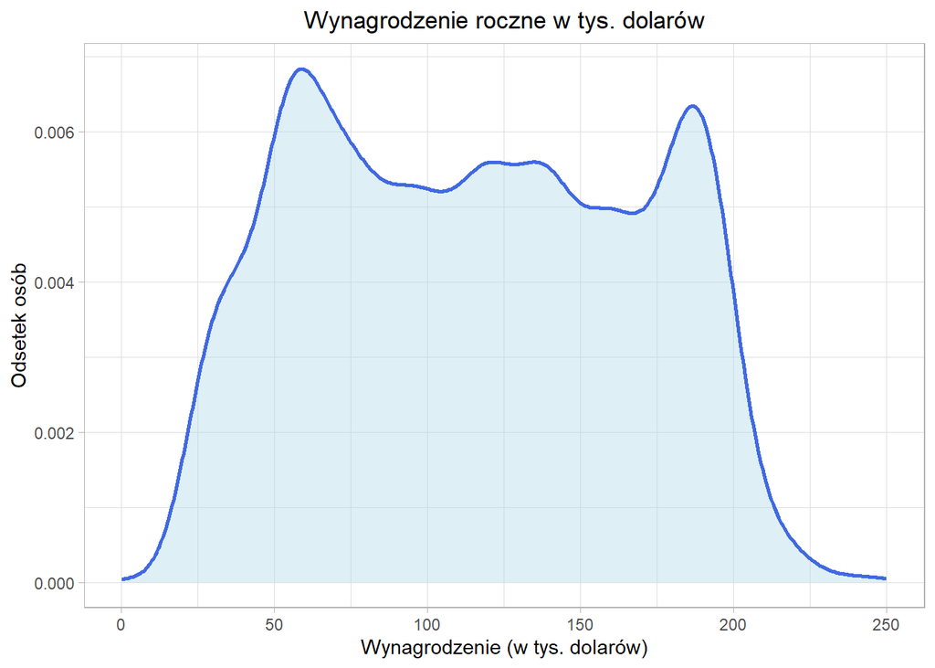

```r
Salary %>%
  mutate(salary_tys = Salary/1000) %>%
  ggplot() +
  geom_density(mapping = aes(x = salary_tys),
               color = "royalblue",
               fill = "lightblue",
               alpha = 0.4,
               linewidth = 1) +
  theme_light() +
  theme(plot.title = element_text(hjust = 0.5)) +
  labs(title = "Wynagrodzenie roczne w tys. dolarów",
       x = "Wynagrodzenie (w tys. dolarów)",
       y = "Odsetek osób")
```

Wyświetlam statystyki opisowe dla powyższej zmiennej:

```r
summary(Salary$Salary)
```

```
##    Min. 1st Qu.  Median    Mean 3rd Qu.    Max.
##     350   70000  115000  115307  160000  250000
```

Sprawdzam ile wynosi kwantyl rzędu 0,01:

```r
quantile(x = Salary$Salary, probs = 0.01)
```

```
##    1%
## 25000
```

Mniej niż 1% osób zarabia co najwyżej 25 000 rocznie, a minimalna wartość wynagrodzenia w zbiorze to 350. Przyglądam się danym, w których wynagrodzenie mieści się w przedziale od 0 do 25 000, ponieważ podejrzewam, że są to błędnie wprowadzone dane:

```r
Salary %>%
  filter(Salary > 0 & Salary < 25000)
```

| Age | Gender | Education.Level | Job.Title | Years.of.Experience | Salary | Country | Race | Senior | Department |
| --- | --- | --- | --- | --- | --- | --- | --- | --- | --- |
| 29 | Male | 1 | other | 1.5 | 350 | USA | Mixed | FALSE | business development |
| 25 | Female | 1 | front end developer | 1.0 | 550 | UK | Mixed | FALSE | IT |
| 23 | Male | 3 | software engineer manager | 1.0 | 579 | UK | Mixed | FALSE | IT |
| 31 | Female | 1 | other | 4.0 | 500 | USA | Asian | FALSE | HR |

Biorąc pod uwagę stanowiska zajmowane przez te osoby oraz państwa w jakich pracują, można stwierdzić, że wynagrodzenie zostało błędnie uzupełnione. Pozbywam się niepoprawnie wprowadzonych danych.

```r
Salary <- Salary %>%
  filter(Salary >= 25000)
```

Dodatkowo, zamieniam wartości wynagrodzeń tak, aby były podane w tysiącach dla zwiększenia czytelności późniejszych wykresów.

```r
Salary <- Salary %>%
  mutate(Salary = Salary/1000)

head(Salary)
```

|  | Age | Gender | Education.Level | Job.Title | Years.of.Experience | Salary | Country | Race | Senior | Department |
| --- | --- | --- | --- | --- | --- | --- | --- | --- | --- | --- |
| 1 | 32 | Male | 1 | software engineer | 5 | 90 | UK | White | FALSE | IT |
| 2 | 28 | Female | 2 | data analyst | 3 | 65 | USA | Mixed | FALSE | data |
| 3 | 45 | Male | 3 | other | 15 | 150 | Canada | White | TRUE | administration |
| 4 | 36 | Female | 1 | sales associate | 7 | 60 | USA | Mixed | FALSE | sales |
| 5 | 52 | Male | 2 | other | 20 | 200 | USA | Asian | FALSE | administration |
| 6 | 29 | Male | 1 | marketing analyst | 2 | 55 | USA | Mixed | FALSE | marketing |

# Zmienne kategoryczne

## Zmienna Gender

Sprawdzam rozkład zmiennej `Gender`:

```r
table(Salary$Gender)
```

```
##
## Female   Male
##   3011   3669
```

Zestaw danych zawiera zbliżoną liczbę informacji o mężycznach i o kobietach, co korzystnie wpływa na dalszą analizę - równowaga płciowa w danych pozwala na bardziej wiarygodne i dokładne wnioski dotyczące różnic między płciami.

## Zmienna Education.Level

Sprawdzam rozkład zmiennej `Education.Level`:

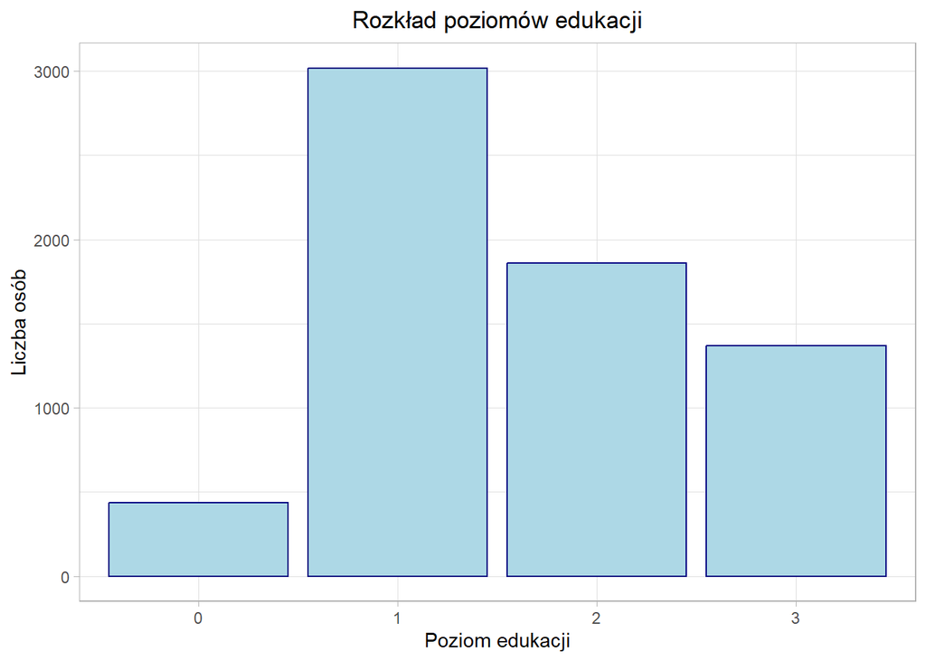

```r
Salary %>%
  ggplot(aes(x = Education.Level)) +
  geom_bar(color = "navyblue",
           fill = "lightblue") +
  theme_light() +
  theme(plot.title = element_text(hjust = 0.5)) +
  labs(title = "Rozkład poziomów edukacji",
       x = "Poziom edukacji",
       y = "Liczba osób")
```

```r
table(Salary$Education.Level)
```

```
##
##    0    1    2    3
##  436 3018 1858 1368
```

Obserwując dane, zauważalne jest, że najmniejszą grupę stanowią osoby z najniższym poziomem wykształcenia (High School). Zdecydowanie najliczniejszą grupę tworzą osoby posiadające stopień Bachelor’s Degree, który odpowiada polskiemu tytułowi licencjata.

## Zmienna Country

Przyglądam się zmiennej `Country`:

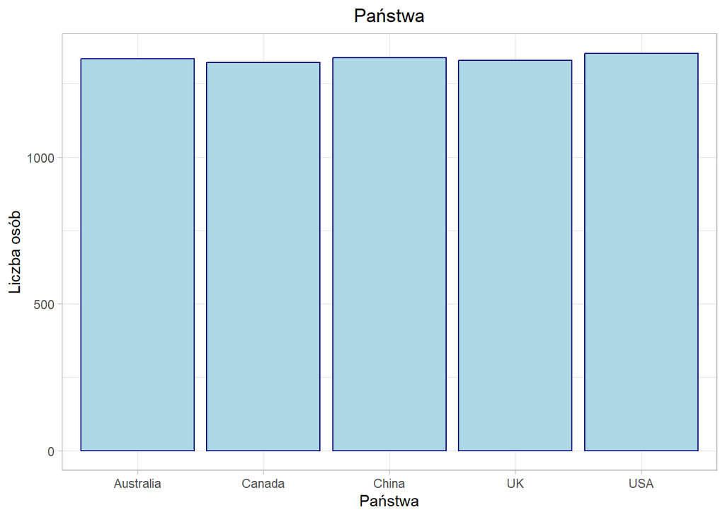

```r
Salary %>%
  ggplot(aes(x = Country)) +
  geom_bar(color = "navyblue",
           fill = "lightblue") +
  theme_light() +
  theme(plot.title = element_text(hjust = 0.5)) +
  labs(title = "Państwa",
       x = "Państwa",
       y = "Liczba osób")
```

```r
table(Salary$Country)
```

```
##
## Australia    Canada     China        UK       USA
##      1335      1322      1339      1330      1354
```

W zestawie danych zauważalna jest równomierna dystrybucja informacji z każdego z państw - grupy nie dominują ilościowo nad innymi, co umożliwia bardziej obiektywne spojrzenie na różnice i podobieństwa.

## Zmienna Race

Przyglądam się zmiennej `Race`:

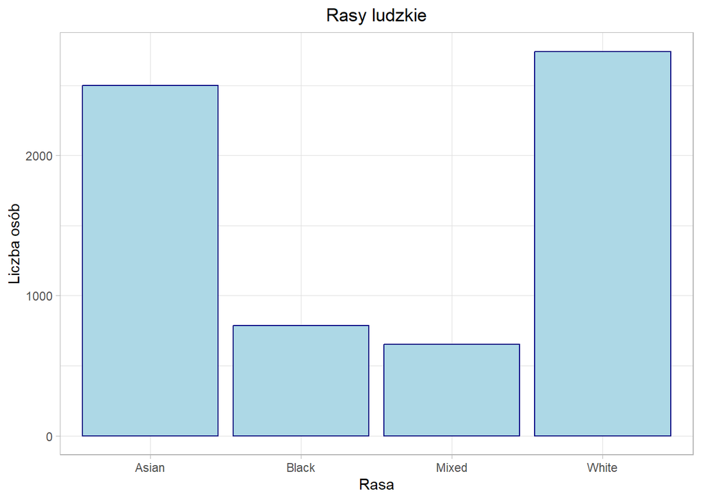

```r
Salary %>%
  ggplot(aes(x = Race)) +
  geom_bar(color = "navyblue",
           fill = "lightblue") +
  theme_light() +
  theme(plot.title = element_text(hjust = 0.5)) +
  labs(title = "Rasy ludzkie",
       x = "Rasa",
       y = "Liczba osób")
```

```r
table(Salary$Race)
```

```
##
## Asian Black Mixed White
##  2498   787   653  2742
```

Jak widać, największą liczebnością charakteryzują się kategorie `Asian` oraz `White` - nie dziwi mnie to ze względu na wcześniej analizowaną zmienną `Country`.

## Zmienna Senior

Przyglądam się zmiennej `Senior`:

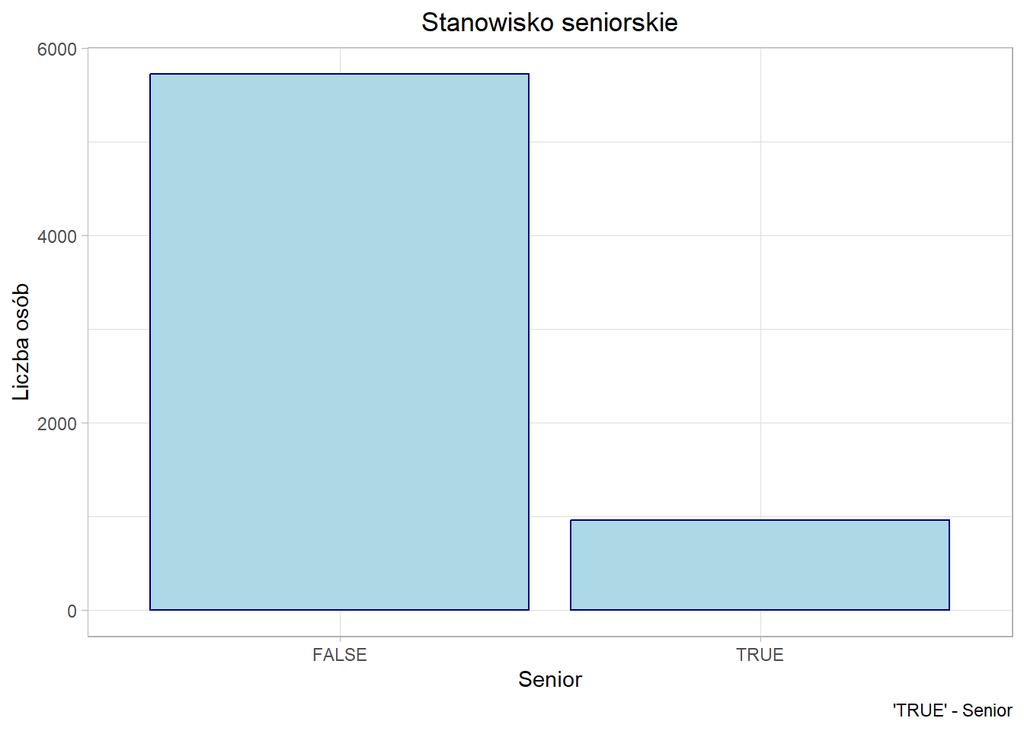

```r
Salary %>%
  ggplot(aes(x = Senior)) +
  geom_bar(color = "navyblue",
           fill = "lightblue") +
  theme_light() +
  theme(plot.title = element_text(hjust = 0.5)) +
  labs(title = "Stanowisko seniorskie",
       x = "Senior",
       y = "Liczba osób",
       caption = "'TRUE' - Senior")
```

```r
table(Salary$Senior)
```

```
##
## FALSE  TRUE
##  5721   959
```

Rozkład tej zmiennej wskazuje, że mniejszość pracowników została sklasyfikowana jako `Senior`, podczas gdy większość stanowią pracownicy niezajmujący tego stanowiska.

# Część badawcza

## Zależności między zmiennymi

W tym etapie analizy badam wzajemne związki między zmiennymi ilościowymi. Celem jest zidentyfikowanie ewentualnych korelacji i wzorców, które mogą istnieć między różnymi cechami w zestawie danych `Salary`.

```r
cor = cor(Salary[, c("Age", "Years.of.Experience", "Salary")],
          method = "spearman")
round(cor, 2)
```

```
##                      Age Years.of.Experience Salary
## Age                 1.00                0.95   0.75
## Years.of.Experience 0.95                1.00   0.86
## Salary              0.75                0.86   1.00
```

Wykorzystuję funkcję `corrplot()` do wizualizacji powiązań między zmiennymi: `Age`, `Years.of.Experience` oraz `Salary`.

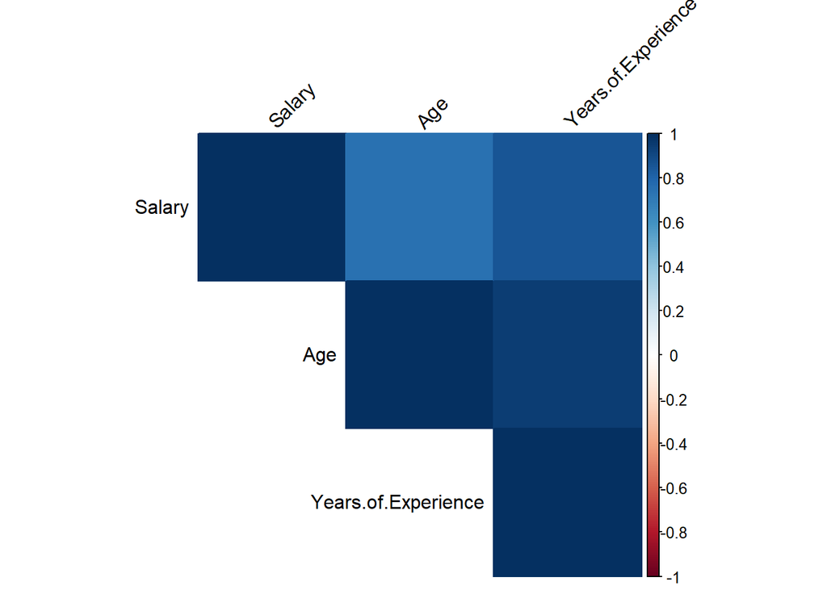

```r
corrplot(cor, method = "color",
         type = "upper",
         order = "hclust",
         tl.col="black",
         tl.srt=45)
```

Wykres pokazuje, że wszystkie zmienne ilościowe z zestawu danych `Salary` są ze sobą silnie skorelowane.

## 1. Rozkład płac w zależności od doświadczenia zawodowego

### 1.1. Jak kształtuje się rozkład płac wśród pracowników o różnym stażu pracy?

Poniższy wykres punktowy przedstawia rozkład płac w kontekście lat doświadczenia zawodowego pracowników. Wykorzystuję skalę tysięcy dla czytelności.

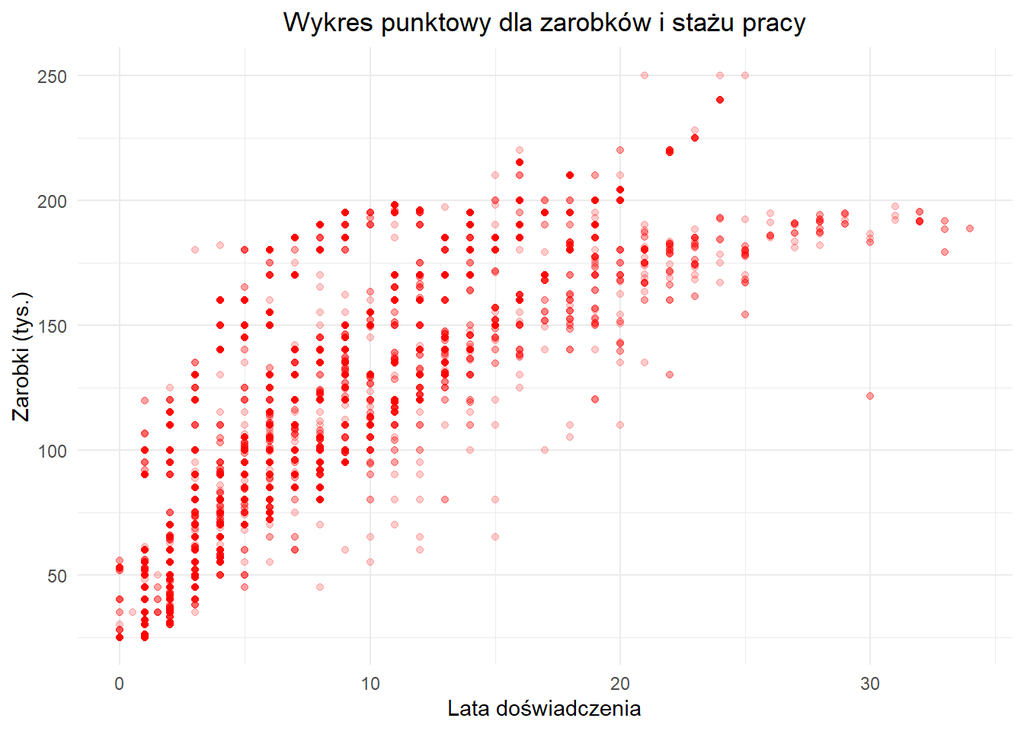

```r
Salary %>%
  ggplot()+
  geom_point(aes(x = Years.of.Experience, y = Salary),
             color = "red",
             alpha = 0.2) +
  labs(title = "Wykres punktowy dla zarobków i stażu pracy",
       x = "Lata doświadczenia",
       y = "Zarobki (tys.)") +
  theme_minimal() +
  theme(plot.title = element_text(hjust = 0.5)) +
  scale_color_brewer(palette = "Set2")
```

Na powyższym wykresie punktowym widoczna jest zgodność z wcześniejszymi wynikami analizy korelacji. Obserwujemy, że istnieje dodatnia zależność między stażem pracy a poziomem wynagrodzenia – pracownicy z większym doświadczeniem zazwyczaj osiągają wyższe zarobki. Niemniej jednak, warto zauważyć pewną stagnację w zarobkach osób z doświadczeniem przekraczającym 20 lat. Obserwacja sugeruje, że w miarę wydłużania się stażu zawodowego, poziom wynagrodzenia w późniejszych etapach kariery stabilizuje się.

### 1.2. Czy wynagrodzenie pracowników na stanowiskach seniorskich rośnie wraz z wydłużaniem się ich lat doświadczenia?

Poniższy wykres punktowy ilustruje zależność między latami doświadczenia a poziomem wynagrodzenia pracowników na stanowiskach seniorskich (oznaczonych różnymi kolorami).

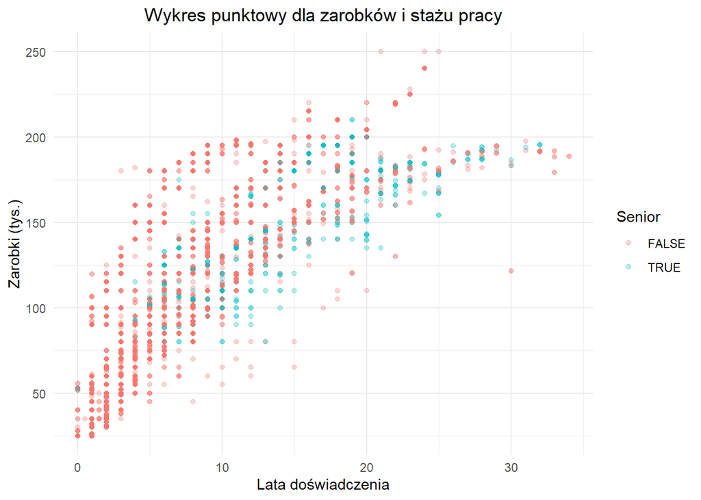

```r
Salary %>%
  ggplot()+
  geom_point(aes(x = Years.of.Experience, y = Salary, col = Senior),
             alpha = 0.3) +
  labs(title = "Wykres punktowy dla zarobków i stażu pracy",
       x = "Lata doświadczenia",
       y = "Zarobki (tys.)") +
  theme_minimal() +
  theme(plot.title = element_text(hjust = 0.5))
```

Poniżej przedstawiam związek między latami doświadczenia a poziomem wynagrodzenia osób na różnych stanowiskach, uwzględniając podział na dwa osobne wykresy:

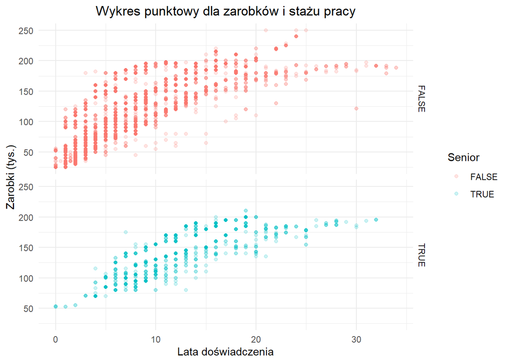

```r
Salary %>%
  ggplot()+
  geom_point(aes(x = Years.of.Experience, y = Salary, col = Senior),
             alpha = 0.2) +
  labs(title = "Wykres punktowy dla zarobków i stażu pracy",
       x = "Lata doświadczenia",
       y = "Zarobki (tys.)") +
  facet_grid(Senior ~ .) +
  theme_minimal() +
  theme(plot.title = element_text(hjust = 0.5))
```

### 1.3. Czy wpływ lat doświadczenia na płace jest zróżnicowany w zależności od działu?

Na wykresie punktowym analizowana jest zależność między latami doświadczenia a poziomem wynagrodzenia w poszczególnych działach z wykorzystaniem funkcji `facet_wrap()`. Wykres ten umożliwia zobaczenie, czy wpływ lat doświadczenia na płace jest zróżnicowany w zależności od przynależności do konkretnego działu.

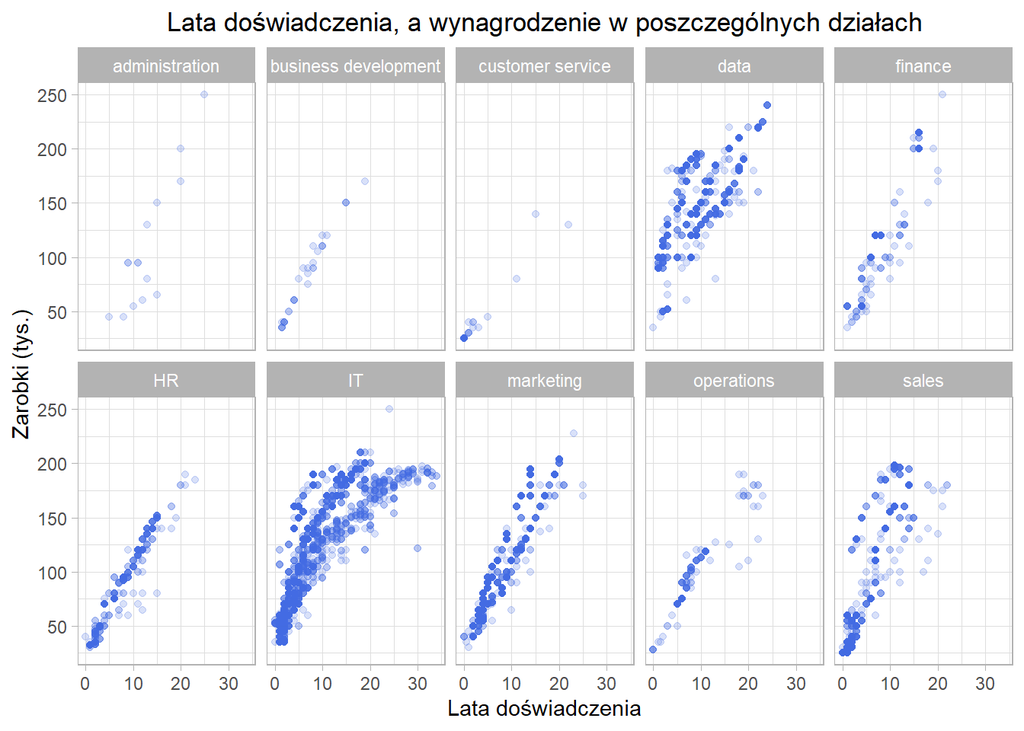

```r
Salary %>%
  ggplot()+
  geom_point(aes(x= Years.of.Experience, y = Salary),
             alpha = 0.2,
             color = "royalblue")+
  facet_wrap(Department ~ ., ncol = 5)+
  theme_light() +
  labs(title = "Lata doświadczenia, a wynagrodzenie w poszczególnych działach",
       x = "Lata doświadczenia",
       y = "Zarobki (tys.)")+
  theme(plot.title = element_text(hjust = 0.5))
```

Zauważam, że poziomy wynagrodzenia różnią się między poszczególnymi działami. Niektóre działy mogą charakteryzować się wyższymi wynagrodzeniami niż inne, co może być wynikiem specyfiki pracy w danym obszarze. Dla stażu poniżej 15 lat, istnieje ogólna tendencja wzrostowa, gdzie zwiększający się staż zawodowy koreluje z wyższymi wynagrodzeniami. Jednakże, dla staży powyżej 15 lat, obserwujemy pewne zróżnicowanie w dynamice wzrostu płac między działami.

## 2. Wpływ poziomu wykształcenia na zarobki

### 2.1. Czy posiadanie wyższego wykształcenia przekłada się na wyższe wynagrodzenie?

Poniższy wykres gęstości przedstawia rozkład zarobków w zależności od poziomu wykształcenia:

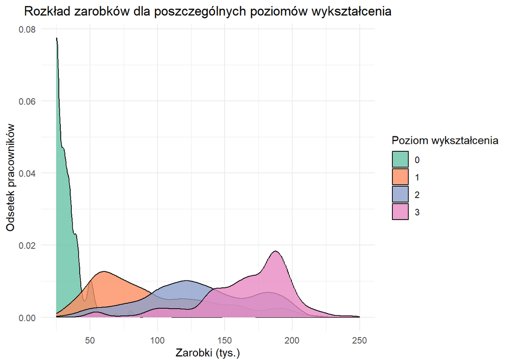

```r
Salary %>%
  ggplot() +
  geom_density(aes(x = Salary,
                     fill = Education.Level),
                     position = "identity",
                     alpha = 0.8) +
  labs(title = "Rozkład zarobków dla poszczególnych poziomów wykształcenia",
       x = "Zarobki (tys.)",
       y = "Odsetek pracowników",
       fill = "Poziom wykształcenia") +
  theme_minimal() +
  theme(plot.title = element_text(hjust = 0.5)) +
  scale_fill_brewer(palette = "Set2")
```

Wyraźnie zauważalne są różnice w rozkładach między poszczególnymi grupami. Możemy zauważyć, że pracownicy z wyższym wykształceniem (w tym doktoratem) często osiągają wyższe zarobki w porównaniu do tych z niższym poziomem edukacji. Spróbuję to jeszcze pokazać za pomocą wykresu pudełkowego.

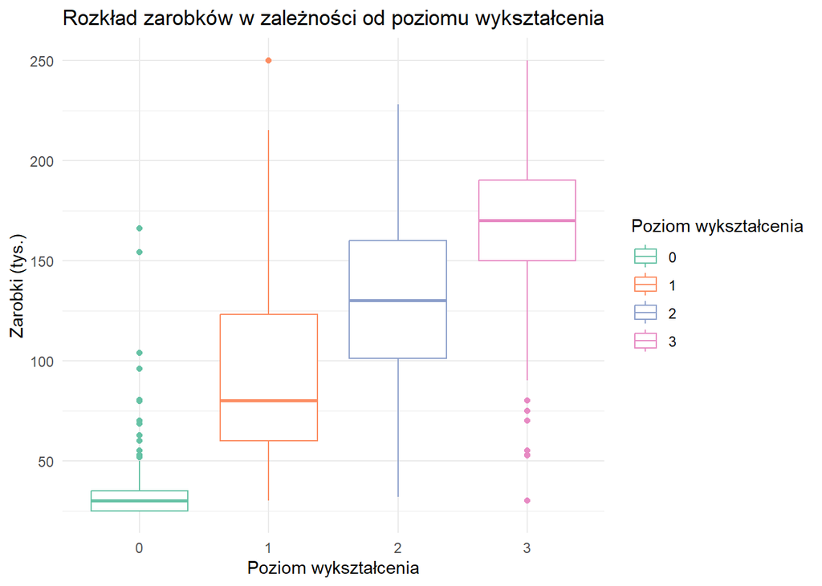

```r
Salary %>%
  ggplot() +
  geom_boxplot(aes(x = Education.Level,
                   y = Salary, color  =
                     Education.Level))+
  labs(title = "Rozkład zarobków w zależności od poziomu wykształcenia",
       x = "Poziom wykształcenia",
       y = "Zarobki (tys.)",
       color = "Poziom wykształcenia") +
  theme_minimal() +
  theme(plot.title = element_text(hjust = 0.5)) +
  scale_color_brewer(palette = "Set2")
```

Obserwujemy, że im wyższy poziom wykształcenia, tym wyższe są mediany oraz górne kwartyle zarobków, co sugeruje, że posiadanie wyższego wykształcenia może być powiązane z wyższymi wynagrodzeniami.

Podsumowując, analiza rozkładu zarobków w kontekście poziomu wykształcenia wyraźnie uwydatnia istotne zróżnicowanie między tymi dwiema zmiennymi. Obserwujemy wyraźne różnice w wynagrodzeniach pracowników o różnym stopniu wykształcenia, gdzie osoby z wyższym wykształceniem prezentują tendencję do zarabiania więcej.

## 3. Zróżnicowanie między płciami

### 3.1. Jakie są różnice w wynagrodzeniach między kobietami a mężczyznami?

Poniższy wykres gęstości przedstawia rozkłady zarobków dla kobiet i mężczyzn. Kolorystyka odróżnia obie grupy, umożliwiając łatwe porównanie rozkładów.

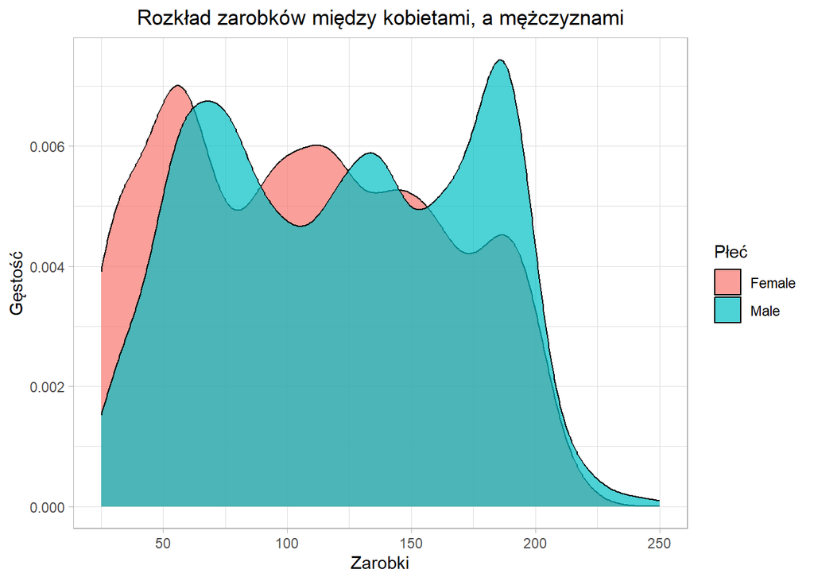

```r
Salary %>%
  ggplot() +
  geom_density(aes(x= Salary, fill = Gender),
               alpha = 0.7) +
  labs(title = "Rozkład zarobków między kobietami, a mężczyznami",
       x = "Zarobki",
       y = "Gęstość",
       fill = "Płeć") +
  theme_light() +
  theme(plot.title = element_text(hjust = 0.5))
```

Wykresy gęstości są do siebie zbliżone, jednak możemy zauważyć, że rozkład zarobków mężczyzn wydaje się być przesunięty ku wyższym wartościom w porównaniu do rozkładu zarobków kobiet. Dodatkowo, obserwujemy różnice w kształcie rozkładów, co sugeruje zróżnicowanie w wynagrodzeniach między płciami.

Rysuję wykres pudełkowy, który również przedstawia rozkład zarobków dla kobiet i mężczyzn:

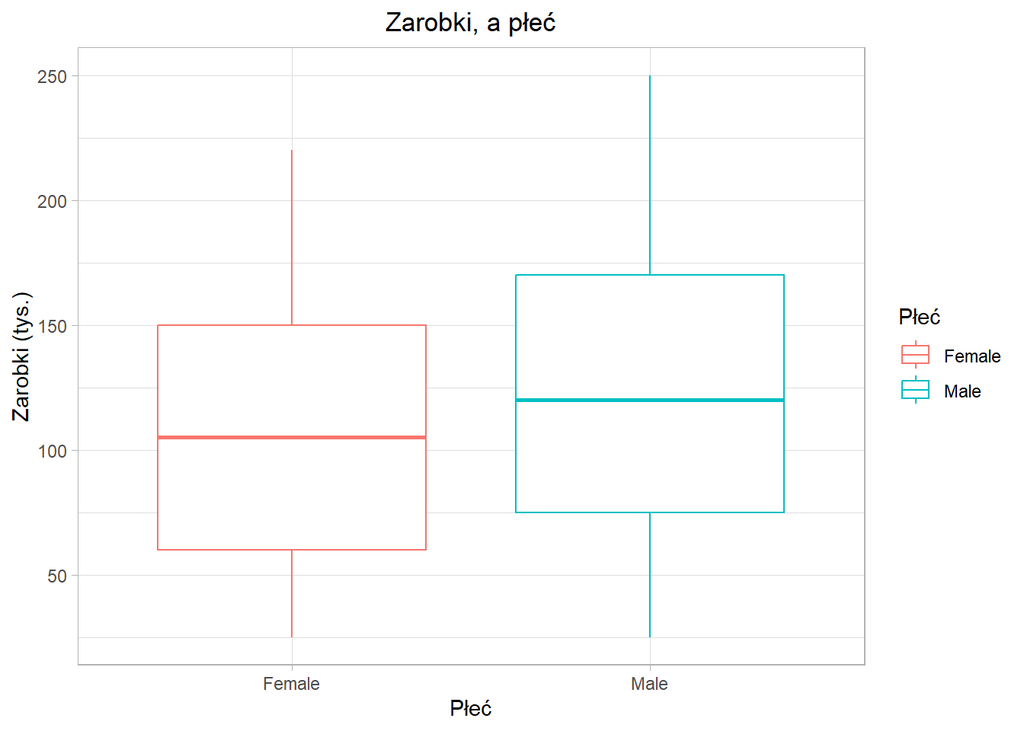

```r
Salary %>%
  ggplot() +
  geom_boxplot(aes(x = Gender, y = Salary, col = Gender))+
  labs(title = "Zarobki, a płeć",
       x = "Płeć",
       y = "Zarobki (tys.)",
       color = "Płeć") +
  theme_light()+
  theme(plot.title = element_text(hjust = 0.5))
```

Wyraźnie widoczne są różnice w zarobkach pomiędzy kobietami a mężczyznami, co potwierdza wcześniejsze spostrzeżenia z wykresu gęstości.

Spoglądam jeszcze na statystyki opisowe dla obu grup:

```r
describeBy(Salary$Salary, Salary$Gender, mat = T)
```

|  | item | group1 | vars | n | mean | sd | median | trimmed | mad | min | max | range | skew | kurtosis | se |
| --- | --- | --- | --- | --- | --- | --- | --- | --- | --- | --- | --- | --- | --- | --- | --- |
| X11 | 1 | Female | 1 | 3011 | 107.9603 | 52.66841 | 105 | 106.8354 | 66.7170 | 25 | 220 | 195 | 0.1473689739 | -1.134188 | 0.9598312 |
| X12 | 2 | Male | 1 | 3669 | 121.4616 | 52.03622 | 120 | 121.7448 | 71.1648 | 25 | 250 | 225 | -0.0009570025 | -1.205336 | 0.8590766 |

Zarówno wykresy pudełkowe, jak i statystyki opisowe, dodatkowo potwierdzają moje wcześniejsze wnioski dotyczące zróżnicowania w wynagrodzeniach między kobietami a mężczyznami. Różnice te są wyraźnie widoczne zarówno na poziomie mediany, jak i w rozpiętości danych.

### 3.2. Czy istnieją obszary, gdzie te różnice są bardziej zauważalne?

Przyglądam się jak wygląda rozkład płci w poszczególnych działach. W tym celu rysuję wykres słupkowy. Kolorystyka pozwala na łatwą identyfikację odsetka mężczyzn i kobiet w każdym z działów.

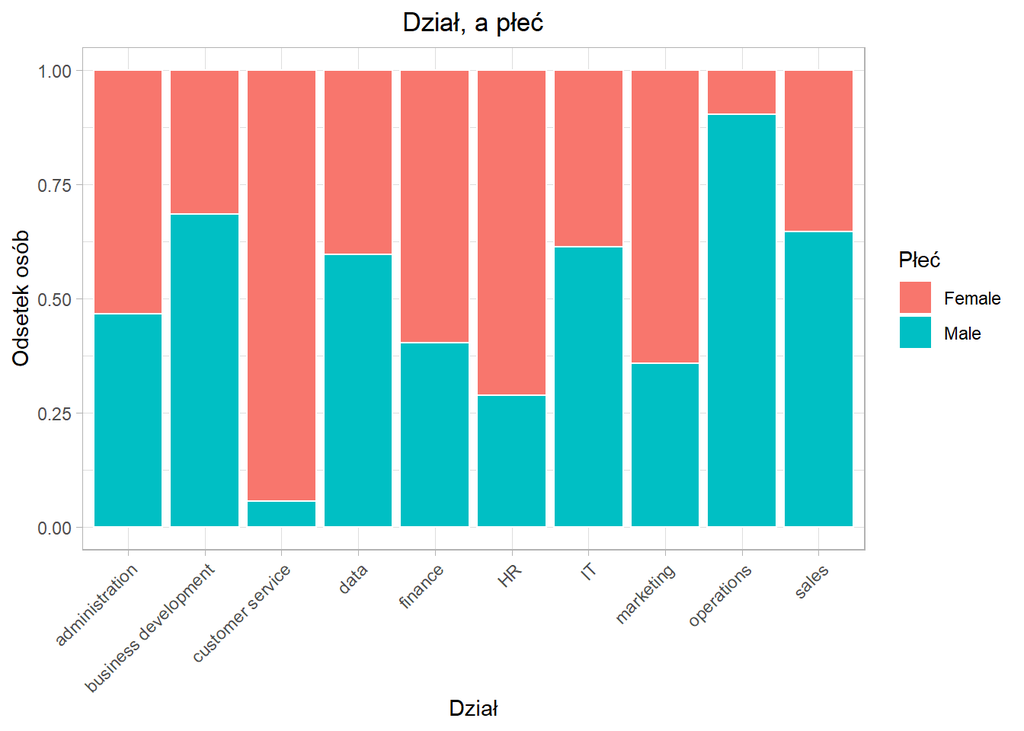

```r
Salary %>%
  ggplot() +
  geom_bar(aes(x = Department,
               fill = Gender),
           color = "white",
           position = "fill") +
  theme_light() +
  labs(title = "Dział, a płeć",
       x = "Dział",
       y = "Odsetek osób",
       fill = "Płeć") +
  theme(axis.text.x = element_text(angle = 45, hjust = 1)) +
  theme(plot.title = element_text(hjust = 0.5))
```

W analizie struktury płciowej w poszczególnych działach zauważalne są pewne zróżnicowania. Działy takie jak `customer service` i `HR` wydają się przeważnie obsadzane przez kobiety, podczas gdy działy związane z technologią i biznesem mają większość pracowników męskich.

Porównuję różnice zarobków między płciami w różnych departamentach, co pozwoli zidentyfikować obszary, gdzie nierówności płacowe mogą być bardziej widoczne. W tym celu rysuję wykresy pudełkowe.

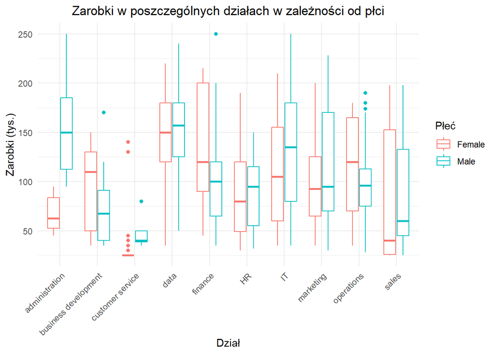

```r
Salary %>%
  ggplot() +
  geom_boxplot(aes(x = Department,
                   y = Salary,
                   col = Gender),
               width = 0.7,
               position = position_dodge2(width = 0.7)) +
  labs(title = "Zarobki w poszczególnych działach w zależności od płci",
       x = "Dział",
       y = "Zarobki (tys.)",
       col = "Płeć") +
  theme_minimal()+
  theme(axis.text.x = element_text(angle = 45, hjust = 1)) +
  theme(plot.title = element_text(hjust = 0.5))
```

### 3.3. Jak różnią się poziomy wykształcenia wśród pracowników w analizowanym zestawie danych w kontekście płci?

Poniższa tabela przedstawia liczebność pracowników w zależności od płci i poziomu wykształcenia.

```r
table(Salary$Gender, Salary$Education.Level)
```

```
##
##             0    1    2    3
##   Female  251 1196 1068  496
##   Male    185 1822  790  872
```

Wśród pracowników dominacja kobiet występuje w poziomach wykształcenia `0` (High School) oraz `2` (Master’s Degree). Z kolei mężczyźni stanowią większość pracowników posiadających stopnie `1` (Bachelor’s Degree) oraz `3` (Doctor of Philosophy). Te wyniki sugerują zróżnicowanie struktury płciowej w zależności od poziomu wykształcenia w analizowanym zbiorze danych. Możemy to sobie jeszcze zwizualizować za pomocą wykresu kolumnowego:

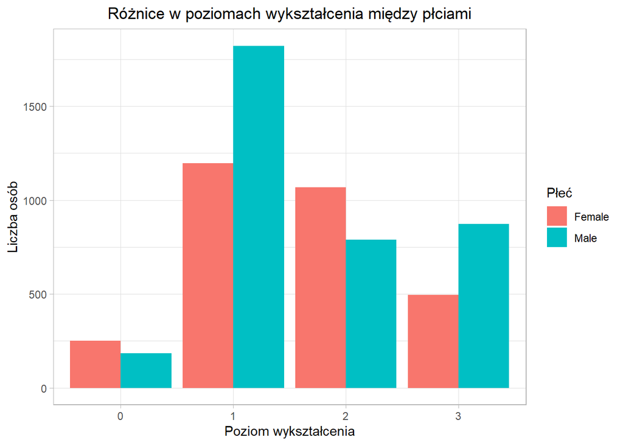

```r
Salary %>%
  ggplot() +
  geom_bar(aes(x = Education.Level,
               fill = Gender),
           position = "dodge") +
  labs(title = "Różnice w poziomach wykształcenia między płciami",
       x = "Poziom wykształcenia",
       y = "Liczba osób",
       fill = "Płeć")+
  theme_light() +
  theme(plot.title = element_text(hjust = 0.5))
```

## 4. Zróżnicowanie pomiędzy rasami

### 4.1. Jakie są różnice w zarobkach między różnymi grupami rasowymi?

Poniższa tabela statystyk opisowych przedstawia różnice w zarobkach między różnymi grupami rasowymi:

```r
describeBy(Salary$Salary, Salary$Race, mat = T)
```

|  | item | group1 | vars | n | mean | sd | median | trimmed | mad | min | max | range | skew | kurtosis | se |
| --- | --- | --- | --- | --- | --- | --- | --- | --- | --- | --- | --- | --- | --- | --- | --- |
| X11 | 1 | Asian | 1 | 2498 | 114.9221 | 51.99269 | 115 | 114.7186 | 66.7170 | 25 | 250 | 225 | 0.06429171 | -1.152090 | 1.040270 |
| X12 | 2 | Black | 1 | 787 | 115.7050 | 51.12890 | 117 | 115.4075 | 63.7518 | 25 | 250 | 225 | 0.06859087 | -1.077341 | 1.822549 |
| X13 | 3 | Mixed | 1 | 653 | 113.9435 | 54.37014 | 110 | 113.3591 | 74.1300 | 25 | 225 | 200 | 0.11472124 | -1.262488 | 2.127668 |
| X14 | 4 | White | 1 | 2742 | 116.0360 | 53.50856 | 115 | 115.9897 | 66.7170 | 25 | 240 | 215 | 0.04186628 | -1.195499 | 1.021856 |

Co ciekawe, z powyższego wynika, że różnice w zarobkach między różnymi grupami rasowymi są znikome. Przyglądam się teraz kwantylom i wartościom minimalnym/maksymalnym, aby uzyskać bardziej szczegółowy obraz:

```r
Salary %>%
  group_by(Race) %>%
  summarise(
    min = min(Salary),
    Q01 = quantile(Salary, 0.01),
    Q1 = quantile(Salary, 0.25),
    Q2 = quantile(Salary, 0.5),
    Q3 = quantile(Salary, 0.75),
    Q99 = quantile(Salary, 0.99),
    max = max(Salary)
    )
```

| Race | min | Q01 | Q1 | Q2 | Q3 | Q99 | max |
| --- | --- | --- | --- | --- | --- | --- | --- |
| Asian | 25 | 25 | 70 | 115 | 160 | 210.0 | 250 |
| Black | 25 | 25 | 70 | 117 | 160 | 210.0 | 250 |
| Mixed | 25 | 25 | 65 | 110 | 160 | 212.4 | 225 |
| White | 25 | 25 | 70 | 115 | 160 | 215.0 | 240 |

Obserwacje zarobków w kwantylach dla różnych grup rasowych wykazują znaczne podobieństwo. Szczególnie interesujące jest to, że minimalne wynagrodzenie dla osób identyfikujących się z grupami `Black` i `White` jest takie samo, co może sugerować pewne równości płacowe między tymi dwoma rasami. Dodatkowo, zwizualizuję to sobie za pomocą wykresów pudełkowych oraz krzywych gęstości:

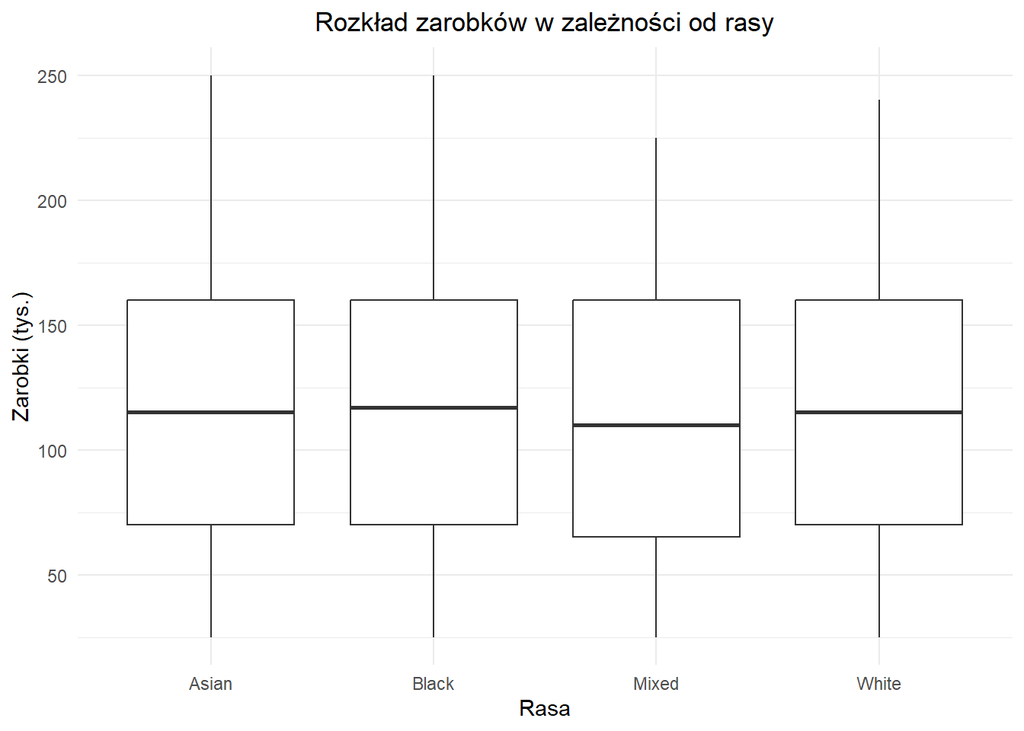

```r
Salary %>%
  ggplot()+
  geom_boxplot(aes(x = Race, y = Salary)) +
  labs(title = "Rozkład zarobków w zależności od rasy",
       x = "Rasa",
       y = "Zarobki (tys.)") +
  theme_minimal()+
  theme(plot.title = element_text(hjust = 0.5))
```

Wykresy pudełkowe zwróciły moją uwagę na to, że osoby klasyfikujące się w rasie `Mixed` zarabiają mniej niż pozostali.

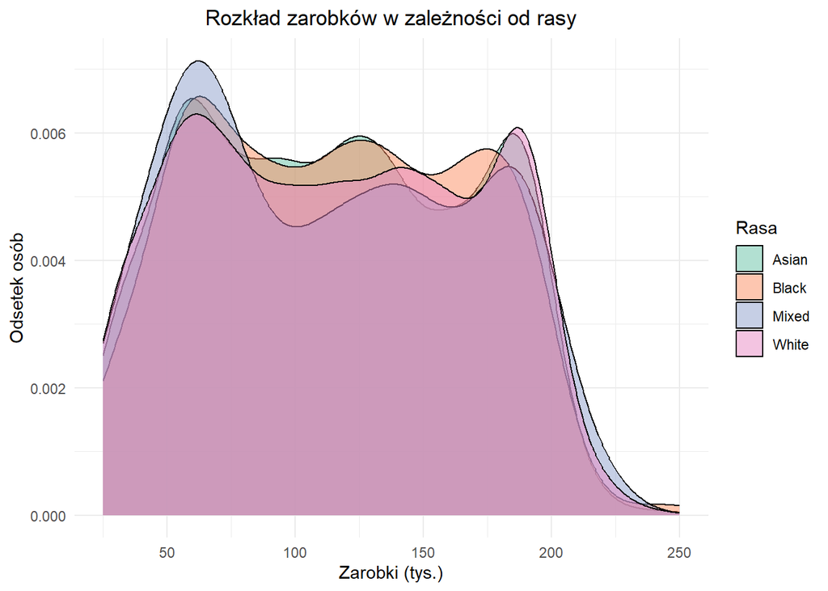

```r
Salary %>%
  ggplot()+
  geom_density(aes(x = Salary, fill = Race),
               alpha = 0.5) +
  labs(title = "Rozkład zarobków w zależności od rasy",
       x = "Zarobki (tys.)",
       y = "Odsetek osób",
       fill = "Rasa") +
  theme_minimal() +
  theme(plot.title = element_text(hjust = 0.5)) +
  scale_fill_brewer(palette = "Set2")
```

### 4.2. Jak kształtuje się zróżnicowanie zarobków w kontekście różnych grup rasowych oraz płci?

Przyglądam się statystykom opisowym dla poszczególnych ras z podziałem na płeć:

```r
Salary %>%
  group_by(Race, Gender) %>%
  summarise(
    min = min(Salary),
    Q01 = quantile(Salary, 0.01),
    Q1 = quantile(Salary, 0.25),
    Q2 = quantile(Salary, 0.5),
    Q3 = quantile(Salary, 0.75),
    Q99 = quantile(Salary, 0.99),
    max = max(Salary)
    )
```

| Race | Gender | min | Q01 | Q1 | Q2 | Q3 | Q99 | max |
| --- | --- | --- | --- | --- | --- | --- | --- | --- |
| Asian | Female | 25 | 25.00 | 60 | 105.00 | 150 | 200.0 | 215 |
| Asian | Male | 25 | 30.00 | 75 | 120.00 | 170 | 210.0 | 250 |
| Black | Female | 25 | 25.00 | 60 | 100.00 | 150 | 200.0 | 215 |
| Black | Male | 25 | 30.00 | 80 | 125.76 | 168 | 215.7 | 250 |
| Mixed | Female | 25 | 25.00 | 55 | 105.00 | 150 | 210.0 | 215 |
| Mixed | Male | 25 | 26.00 | 70 | 120.00 | 170 | 219.0 | 225 |
| White | Female | 25 | 25.00 | 60 | 110.00 | 150 | 215.0 | 220 |
| White | Male | 25 | 27.64 | 75 | 120.00 | 170 | 219.0 | 240 |

W każdej z ras mężczyźni zarabiają więcej, a co więcej - ich płace są bardzo do siebie zbliżone.

Modyfikuję wykres z poprzedniej części o uwzględnienie podziału ze względu na płeć:

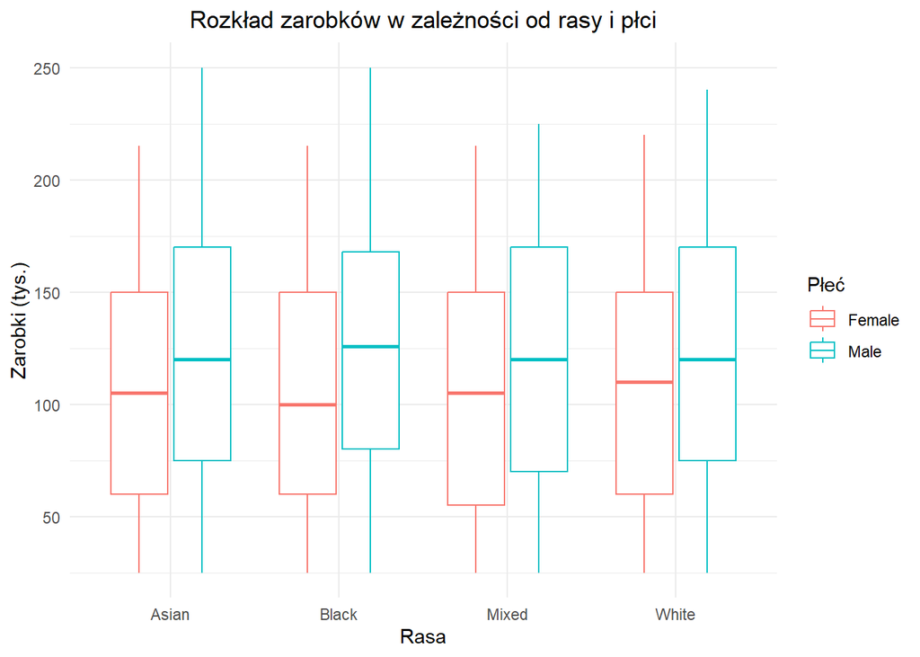

```r
Salary %>%
  ggplot()+
  geom_boxplot(aes(x = Race, y = Salary, col = Gender)) +
  labs(title = "Rozkład zarobków w zależności od rasy i płci",
       x = "Rasa",
       y = "Zarobki (tys.)",
       col = "Płeć") +
  theme_minimal()+
  theme(plot.title = element_text(hjust = 0.5))
```

Analiza zarobków w poszczególnych grupach rasowych wskazuje na istotne różnice między płciami. W każdej z badanych ras to mężczyźni osiągają wyższe zarobki niż kobiety. Co ciekawe, obserwujemy jednolite wynagrodzenia zarówno dla mężczyzn, jak i kobiet w obrębie każdej z ras, co może być istotnym spostrzeżeniem w kontekście równości płacowej wewnątrz poszczególnych grup rasowych.

## 5. Analiza zależności w kontekście krajów

Na początku przyglądam się rozkładowi zarobków w zależności od kraju pochodzenia respondenta:

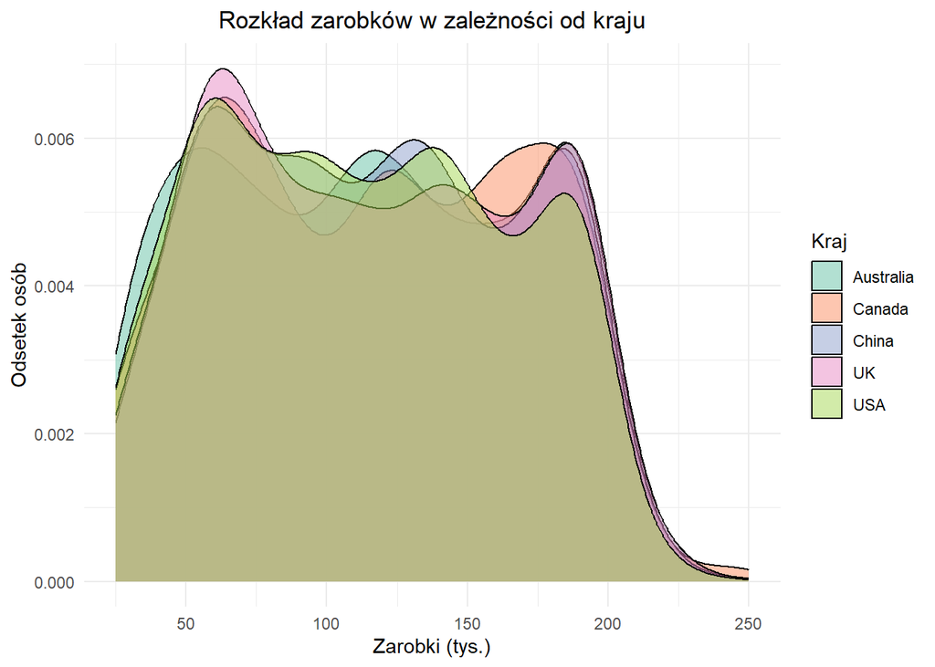

```r
Salary %>%
  ggplot()+
  geom_density(aes(x = Salary, fill = Country),
               alpha = 0.5) +
  labs(title = "Rozkład zarobków w zależności od kraju",
       x = "Zarobki (tys.)",
       y = "Odsetek osób",
       fill = "Kraj") +
  theme_minimal() +
  theme(plot.title = element_text(hjust = 0.5)) +
  scale_fill_brewer(palette = "Set2")
```

Jak widać, rozkłady zarobków dla poszczególnych państw są do siebie bardzo zbliżone, co sugeruje równość płacową.

### 5.1. Czy płaca roczna różni się między płciami w badanych krajach?

Przyglądam się zależnościom między płacą roczną a płcią pracowników w różnych krajach. Poniżej wyznaczam statystyki opisowe dla zarobków w poszczególnych krajach z podziałem na płeć:

```r
Salary %>%
  group_by(Country, Gender) %>%
  summarise(
    min = min(Salary),
    Q01 = quantile(Salary, 0.01),
    Q1 = quantile(Salary, 0.25),
    Q2 = quantile(Salary, 0.5),
    Q3 = quantile(Salary, 0.75),
    Q99 = quantile(Salary, 0.99),
    max = max(Salary)
    )
```

| Country | Gender | min | Q01 | Q1 | Q2 | Q3 | Q99 | max |
| --- | --- | --- | --- | --- | --- | --- | --- | --- |
| Australia | Female | 25 | 25.00 | 55.5 | 110 | 154.2597 | 200.00 | 215 |
| Australia | Male | 25 | 28.00 | 75.0 | 120 | 170.0000 | 217.20 | 225 |
| Canada | Female | 25 | 25.00 | 58.5 | 105 | 160.0000 | 200.00 | 215 |
| Canada | Male | 25 | 26.78 | 75.0 | 130 | 170.0000 | 224.88 | 250 |
| China | Female | 25 | 25.00 | 65.0 | 110 | 151.0000 | 215.00 | 215 |
| China | Male | 26 | 33.41 | 75.0 | 120 | 170.0000 | 210.00 | 240 |
| UK | Female | 25 | 25.00 | 60.0 | 105 | 150.0000 | 200.00 | 215 |
| UK | Male | 25 | 31.00 | 72.0 | 120 | 170.1695 | 219.00 | 240 |
| USA | Female | 25 | 25.00 | 60.0 | 100 | 145.0000 | 200.00 | 220 |
| USA | Male | 25 | 26.00 | 75.0 | 120 | 168.2152 | 210.00 | 240 |

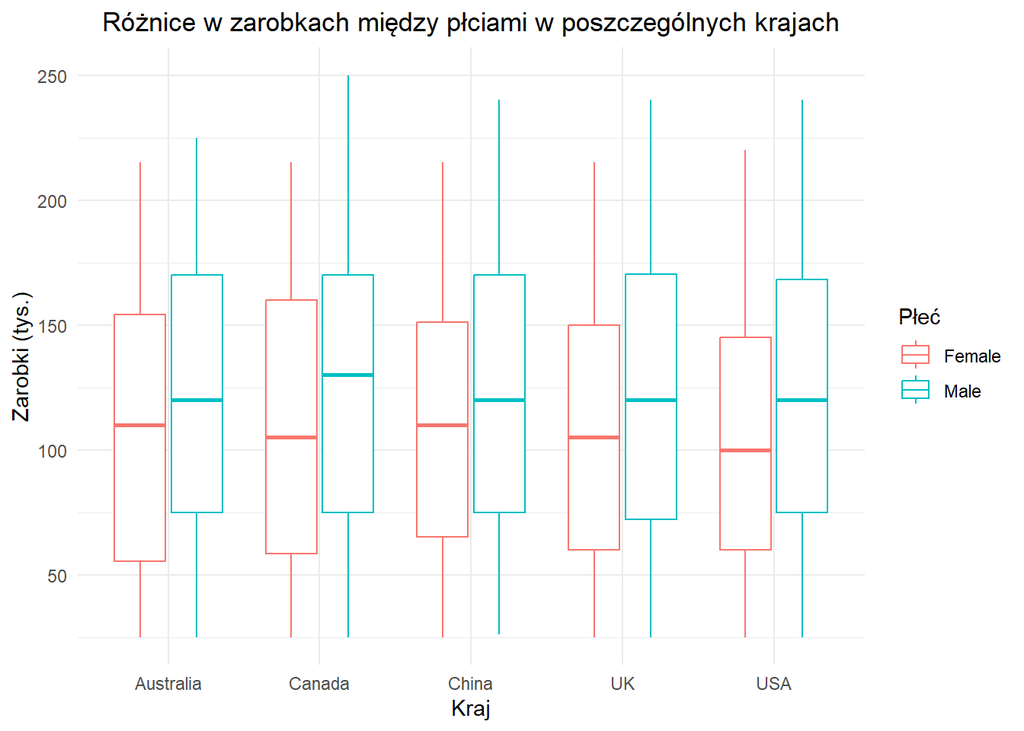

```r
Salary %>%
  ggplot()+
  geom_boxplot(aes(x = Country, y = Salary, col = Gender))+
  labs(title = "Różnice w zarobkach między płciami w poszczególnych krajach",
       x = "Kraj",
       y = "Zarobki (tys.)",
       col = "Płeć") +
  theme_minimal() +
  theme(plot.title = element_text(hjust = 0.5))
```

W wynikach analizy płac rocznych w poszczególnych krajach obserwowalne są pewne zauważalne tendencje. W każdym z badanych państw można stwierdzić, że zarobki kobiet skłaniają się ku niższym wartościom. Innymi słowy, płace kobiet są często niższe niż płace mężczyzn w każdym z badanych krajów. Ten wynik sugeruje obecność pewnej płciowej dysproporcji w zakresie wynagrodzeń.

### 5.2. Czy związek między wiekiem a wynagrodzeniem rocznym jest podobny we wszystkich badanych krajach?

Poniższy wykres punktowy przedstawia rozkład płac w kontekście wieku respondentów. Wykorzystuję skalę kolorów do odróżnienia poszczególnych państw.

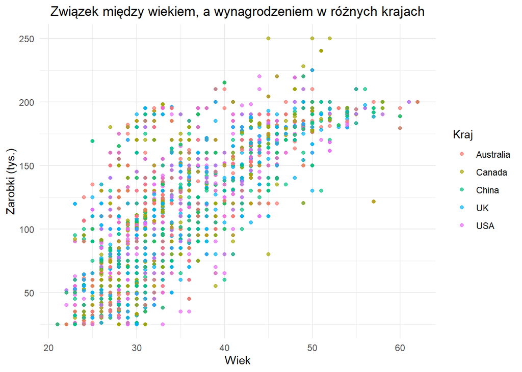

```r
Salary %>%
  ggplot()+
  geom_point(aes(x = Age,
                 y = Salary,
                 col = Country),
             alpha = 0.7)+
  labs(title = "Związek między wiekiem, a wynagrodzeniem w różnych krajach",
       x = "Wiek",
       y = "Zarobki (tys.)",
       col = "Kraj") +
  theme_minimal() +
  theme(plot.title = element_text(hjust = 0.5)) +
  scale_fill_brewer(palette = "Set2")
```

Poniżej przedstawiam związek między wiekiem a poziomem wynagrodzenia osób z różnych państw, uwzględniając podział na osobne wykresy:

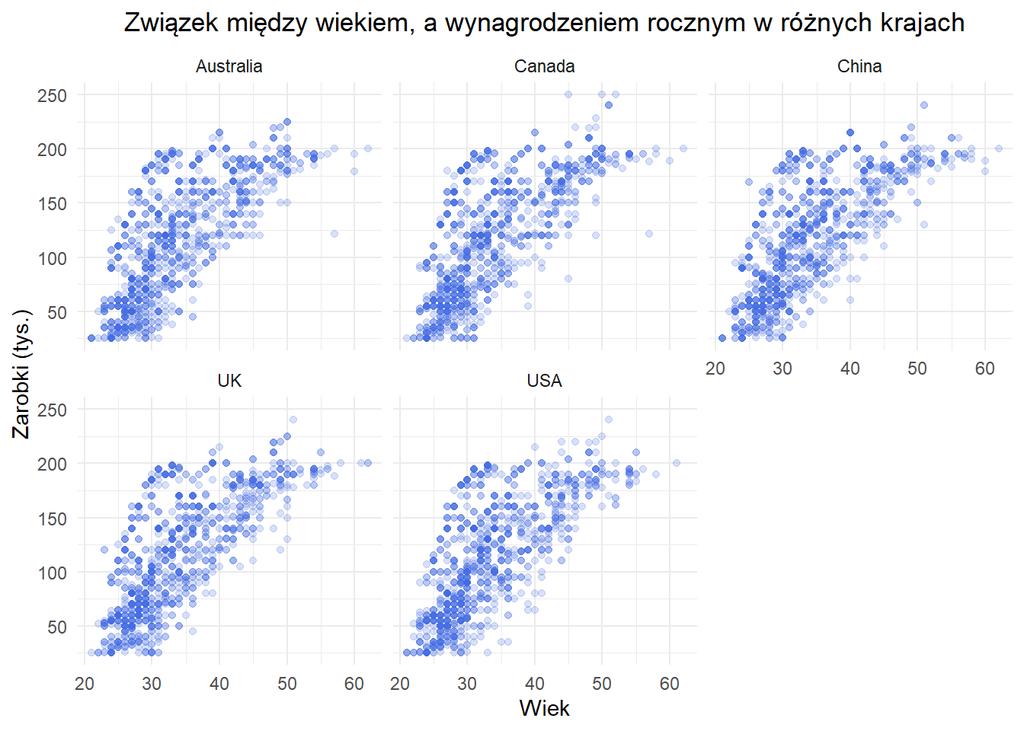

```r
Salary %>%
  ggplot()+
  geom_point(aes(x=Age, y = Salary),
             col = "royalblue",
             alpha = 0.2) +
  labs(title = "Związek między wiekiem, a wynagrodzeniem rocznym w różnych krajach",
       x = "Wiek",
       y = "Zarobki (tys.)") +
  facet_wrap(~ Country, ncol = 3) +
  theme_minimal() +
  theme(plot.title = element_text(hjust = 0.5))
```

Na podstawie wykresów punktowych przedstawiających związek między wiekiem a wynagrodzeniem rocznym w różnych krajach, można zauważyć pewne ogólne tendencje. W większości krajów widać tendencję do wzrostu wynagrodzenia wraz z wiekiem. Co ciekawe, w każdym z krajów w grupie wiekowej od 45 do 55 lat widoczna jest grupa osób z wynagrodzeniem odstającym od reszty. Sprawdzam, kim są te osoby:

```r
Salary %>%
  filter(Age >=45 & Age <= 55,
         Salary > 200) %>%
    select(Age,Gender, Education.Level, Years.of.Experience, Senior, Country) %>%
  summary()
```

```
##       Age           Gender   Education.Level Years.of.Experience
##  Min.   :45.00   Female: 3   0: 0            Min.   :18.00
##  1st Qu.:48.00   Male  :87   1: 2            1st Qu.:18.00
##  Median :48.00               2:16            Median :20.00
##  Mean   :48.62               3:72            Mean   :20.34
##  3rd Qu.:50.00                               3rd Qu.:22.00
##  Max.   :55.00                               Max.   :25.00
##    Senior             Country
##  Mode :logical   Australia:16
##  FALSE:88        Canada   :23
##  TRUE :2         China    :15
##                  UK       :20
##                  USA      :16
##
```

# Wnioski i podsumowanie

Analiza EDA pozwoliła na zidentyfikowanie kilku istotnych trendów i zależności w danych dotyczących płac. Widoczne są pewne nierówności płacowe między płciami, różnice w zarobkach w zależności od poziomu wykształcenia, doświadczenia zawodowego oraz obszarów zawodowych.